# Airbnb Review Scores Rating Exploration and Prediction: Empirical Evidence from Hong Kong

15/01/2021

### 1. Abstract & Import Data

Inspired by the business success of Airbnb and the developed tourism industry in Hong Kong, in this project, we will explore the determinants of the Airbnb customer experience and aim to improve the performance of Airbnb hosts in Hong Kong. On the Airbnb website, listings are evaluated through six dimensions – accuracy, communication, cleanliness, check-in, location, and value. The empirical project will firstly analyze the order of importance of these six dimensions. Then using the dataset sourced from Inside Airbnb, we will investigate which features are crucial for customer satisfaction. Lastly, we will build customer experience models to predict the quality of listings.

#### 1.1. Import packages

```r
# import packages
library(tidyverse)
# library(geojsonio)
library(ggplot2)
library(plotly)
library(BBmisc)
library(corrplot)
library(e1071)
library(skimr)
library(stargazer)
library(tm)
library(tidytext)
library(DescTools)
# library(ISLR)
library(glmnet)
# library(factoextra)
library(randomForest)
library(MASS)
```

#### 1.2. Set seed

```r
# set seed
set.seed(123987)
```

#### 1.3. Import data

```r
listings <- read.csv("listings.csv", header = TRUE, sep = ",")
```

#### 1.4. Data skimming

```r
skim(listings)
```

Data summary

| Name | listings |
| --- | --- |
| Number of rows | 11187 |
| Number of columns | 106 |
| _______________________ |  |
| Column type frequency: |  |
| character | 62 |
| logical | 5 |
| numeric | 39 |
| ________________________ |  |
| Group variables | None |

**Variable type: character**

| skim_variable | n_missing | complete_rate | min | max | empty | n_unique | whitespace |
| --- | --- | --- | --- | --- | --- | --- | --- |
| listing_url | 0 | 1 | 34 | 37 | 0 | 11187 | 0 |
| last_scraped | 0 | 1 | 10 | 10 | 0 | 4 | 0 |
| name | 0 | 1 | 0 | 250 | 8 | 10901 | 0 |
| summary | 0 | 1 | 0 | 1452 | 756 | 7999 | 0 |
| space | 0 | 1 | 0 | 2560 | 4528 | 4893 | 0 |
| description | 0 | 1 | 0 | 2862 | 521 | 8954 | 0 |
| experiences_offered | 0 | 1 | 4 | 4 | 0 | 1 | 0 |
| neighborhood_overview | 0 | 1 | 0 | 2830 | 5879 | 3576 | 0 |
| notes | 1 | 1 | 0 | 2138 | 6861 | 2413 | 0 |
| transit | 0 | 1 | 0 | 1837 | 5598 | 3668 | 0 |
| access | 0 | 1 | 0 | 1774 | 6790 | 2873 | 0 |
| interaction | 0 | 1 | 0 | 1778 | 6119 | 2983 | 0 |
| house_rules | 0 | 1 | 0 | 1830 | 6217 | 3170 | 0 |
| picture_url | 0 | 1 | 81 | 146 | 0 | 10607 | 0 |
| host_url | 0 | 1 | 39 | 43 | 0 | 4874 | 0 |
| host_name | 0 | 1 | 0 | 43 | 12 | 2847 | 0 |
| host_since | 0 | 1 | 0 | 10 | 12 | 2356 | 0 |
| host_location | 0 | 1 | 0 | 161 | 38 | 435 | 0 |
| host_about | 0 | 1 | 0 | 4413 | 4311 | 2462 | 9 |
| host_response_time | 0 | 1 | 0 | 18 | 12 | 6 | 0 |
| host_response_rate | 0 | 1 | 0 | 4 | 12 | 60 | 0 |
| host_acceptance_rate | 0 | 1 | 0 | 4 | 12 | 75 | 0 |
| host_is_superhost | 0 | 1 | 0 | 1 | 12 | 3 | 0 |
| host_thumbnail_url | 0 | 1 | 0 | 106 | 12 | 4852 | 0 |
| host_picture_url | 0 | 1 | 0 | 109 | 12 | 4852 | 0 |
| host_neighbourhood | 0 | 1 | 0 | 26 | 2525 | 164 | 0 |
| host_verifications | 0 | 1 | 2 | 156 | 0 | 265 | 0 |
| host_has_profile_pic | 0 | 1 | 0 | 1 | 12 | 3 | 0 |
| host_identity_verified | 0 | 1 | 0 | 1 | 12 | 3 | 0 |
| street | 0 | 1 | 13 | 147 | 0 | 688 | 0 |
| neighbourhood | 0 | 1 | 0 | 26 | 1284 | 57 | 0 |
| neighbourhood_cleansed | 0 | 1 | 5 | 17 | 0 | 18 | 0 |
| city | 0 | 1 | 0 | 67 | 770 | 384 | 2 |
| state | 0 | 1 | 0 | 67 | 369 | 179 | 1 |
| zipcode | 6 | 1 | 0 | 20 | 10452 | 123 | 6 |
| market | 0 | 1 | 0 | 22 | 9 | 13 | 0 |
| smart_location | 0 | 1 | 9 | 78 | 0 | 387 | 0 |
| country_code | 0 | 1 | 2 | 2 | 0 | 3 | 0 |
| country | 0 | 1 | 5 | 14 | 0 | 3 | 0 |
| is_location_exact | 0 | 1 | 1 | 1 | 0 | 2 | 0 |
| property_type | 0 | 1 | 3 | 22 | 0 | 41 | 0 |
| room_type | 0 | 1 | 10 | 15 | 0 | 4 | 0 |
| bed_type | 0 | 1 | 5 | 13 | 0 | 5 | 0 |
| amenities | 0 | 1 | 2 | 1128 | 0 | 8558 | 0 |
| price | 0 | 1 | 5 | 10 | 0 | 374 | 0 |
| weekly_price | 0 | 1 | 0 | 10 | 10601 | 269 | 0 |
| monthly_price | 0 | 1 | 0 | 11 | 10480 | 317 | 0 |
| security_deposit | 0 | 1 | 0 | 10 | 5677 | 232 | 0 |
| cleaning_fee | 0 | 1 | 0 | 9 | 5055 | 260 | 0 |
| extra_people | 0 | 1 | 5 | 9 | 0 | 184 | 0 |
| calendar_updated | 0 | 1 | 5 | 13 | 0 | 78 | 0 |
| has_availability | 0 | 1 | 1 | 1 | 0 | 1 | 0 |
| calendar_last_scraped | 0 | 1 | 10 | 10 | 0 | 4 | 0 |
| first_review | 0 | 1 | 0 | 10 | 4155 | 1987 | 0 |
| last_review | 0 | 1 | 0 | 10 | 4155 | 1366 | 0 |
| requires_license | 0 | 1 | 1 | 1 | 0 | 1 | 0 |
| license | 0 | 1 | 0 | 18 | 11157 | 12 | 0 |
| instant_bookable | 0 | 1 | 1 | 1 | 0 | 2 | 0 |
| is_business_travel_ready | 0 | 1 | 1 | 1 | 0 | 1 | 0 |
| cancellation_policy | 0 | 1 | 6 | 27 | 0 | 6 | 0 |
| require_guest_profile_picture | 0 | 1 | 1 | 1 | 0 | 2 | 0 |
| require_guest_phone_verification | 0 | 1 | 1 | 1 | 0 | 2 | 0 |

**Variable type: logical**

| skim_variable | n_missing | complete_rate | mean | count |
| --- | --- | --- | --- | --- |
| thumbnail_url | 11187 | 0 | NaN | : |
| medium_url | 11187 | 0 | NaN | : |
| xl_picture_url | 11187 | 0 | NaN | : |
| neighbourhood_group_cleansed | 11187 | 0 | NaN | : |
| jurisdiction_names | 11187 | 0 | NaN | : |

**Variable type: numeric**

| skim_variable | n_missing | complete_rate | mean | sd | p0 | p25 | p50 | p75 | p100 | hist |
| --- | --- | --- | --- | --- | --- | --- | --- | --- | --- | --- |
| id | 0 | 1.00 | 2.502385e+07 | 11670770.80 | 6.907400e+04 | 1.627071e+07 | 2.625903e+07 | 3.473919e+07 | 4.379768e+07 | ▃▅▆▇▇ |
| scrape_id | 0 | 1.00 | 2.020062e+13 | 0.00 | 2.020062e+13 | 2.020062e+13 | 2.020062e+13 | 2.020062e+13 | 2.020062e+13 | ▁▁▇▁▁ |
| host_id | 0 | 1.00 | 8.840541e+07 | 87436601.62 | 3.217200e+04 | 1.689883e+07 | 5.247315e+07 | 1.386492e+08 | 3.494574e+08 | ▇▃▂▂▁ |
| host_listings_count | 12 | 1.00 | 4.847000e+01 | 104.68 | 0.000000e+00 | 1.000000e+00 | 5.000000e+00 | 2.200000e+01 | 3.860000e+02 | ▇▁▁▁▁ |
| host_total_listings_count | 12 | 1.00 | 4.847000e+01 | 104.68 | 0.000000e+00 | 1.000000e+00 | 5.000000e+00 | 2.200000e+01 | 3.860000e+02 | ▇▁▁▁▁ |
| latitude | 0 | 1.00 | 2.230000e+01 | 0.05 | 2.216000e+01 | 2.228000e+01 | 2.230000e+01 | 2.231000e+01 | 2.256000e+01 | ▁▇▁▁▁ |
| longitude | 0 | 1.00 | 1.141600e+02 | 0.04 | 1.138600e+02 | 1.141500e+02 | 1.141700e+02 | 1.141800e+02 | 1.143600e+02 | ▁▁▃▇▁ |
| accommodates | 0 | 1.00 | 2.820000e+00 | 2.18 | 1.000000e+00 | 2.000000e+00 | 2.000000e+00 | 3.000000e+00 | 1.600000e+01 | ▇▁▁▁▁ |
| bathrooms | 17 | 1.00 | 1.160000e+00 | 0.57 | 0.000000e+00 | 1.000000e+00 | 1.000000e+00 | 1.000000e+00 | 1.100000e+01 | ▇▁▁▁▁ |
| bedrooms | 38 | 1.00 | 1.090000e+00 | 0.85 | 0.000000e+00 | 1.000000e+00 | 1.000000e+00 | 1.000000e+00 | 1.100000e+01 | ▇▁▁▁▁ |
| beds | 69 | 0.99 | 1.680000e+00 | 1.44 | 0.000000e+00 | 1.000000e+00 | 1.000000e+00 | 2.000000e+00 | 2.000000e+01 | ▇▁▁▁▁ |
| square_feet | 11146 | 0.00 | 3.992700e+02 | 619.44 | 0.000000e+00 | 0.000000e+00 | 1.400000e+02 | 6.000000e+02 | 3.200000e+03 | ▇▂▁▁▁ |
| guests_included | 0 | 1.00 | 1.390000e+00 | 1.06 | 1.000000e+00 | 1.000000e+00 | 1.000000e+00 | 1.000000e+00 | 1.600000e+01 | ▇▁▁▁▁ |
| minimum_nights | 0 | 1.00 | 9.760000e+00 | 28.27 | 1.000000e+00 | 1.000000e+00 | 2.000000e+00 | 7.000000e+00 | 1.100000e+03 | ▇▁▁▁▁ |
| maximum_nights | 0 | 1.00 | 3.856520e+05 | 28712475.39 | 1.000000e+00 | 3.650000e+02 | 1.125000e+03 | 1.125000e+03 | 2.147484e+09 | ▇▁▁▁▁ |
| minimum_minimum_nights | 0 | 1.00 | 9.610000e+00 | 27.96 | 1.000000e+00 | 1.000000e+00 | 2.000000e+00 | 7.000000e+00 | 1.100000e+03 | ▇▁▁▁▁ |
| maximum_minimum_nights | 0 | 1.00 | 1.000000e+01 | 29.09 | 1.000000e+00 | 1.000000e+00 | 2.000000e+00 | 7.000000e+00 | 1.100000e+03 | ▇▁▁▁▁ |
| minimum_maximum_nights | 0 | 1.00 | 3.856853e+05 | 28712474.94 | 1.000000e+00 | 3.650000e+02 | 1.125000e+03 | 1.125000e+03 | 2.147484e+09 | ▇▁▁▁▁ |
| maximum_maximum_nights | 0 | 1.00 | 3.856990e+05 | 28712474.76 | 1.000000e+00 | 3.650000e+02 | 1.125000e+03 | 1.125000e+03 | 2.147484e+09 | ▇▁▁▁▁ |
| minimum_nights_avg_ntm | 0 | 1.00 | 9.790000e+00 | 28.17 | 1.000000e+00 | 1.000000e+00 | 2.000000e+00 | 7.000000e+00 | 1.100000e+03 | ▇▁▁▁▁ |
| maximum_nights_avg_ntm | 0 | 1.00 | 3.856961e+05 | 28712474.80 | 1.000000e+00 | 3.650000e+02 | 1.125000e+03 | 1.125000e+03 | 2.147484e+09 | ▇▁▁▁▁ |
| availability_30 | 0 | 1.00 | 1.552000e+01 | 14.01 | 0.000000e+00 | 0.000000e+00 | 2.000000e+01 | 3.000000e+01 | 3.000000e+01 | ▇▁▁▁▇ |
| availability_60 | 0 | 1.00 | 3.280000e+01 | 27.91 | 0.000000e+00 | 0.000000e+00 | 4.700000e+01 | 6.000000e+01 | 6.000000e+01 | ▆▁▁▁▇ |
| availability_90 | 0 | 1.00 | 5.062000e+01 | 41.70 | 0.000000e+00 | 0.000000e+00 | 7.600000e+01 | 9.000000e+01 | 9.000000e+01 | ▆▁▁▁▇ |
| availability_365 | 0 | 1.00 | 1.678100e+02 | 157.00 | 0.000000e+00 | 0.000000e+00 | 1.080000e+02 | 3.640000e+02 | 3.650000e+02 | ▇▂▂▁▇ |
| number_of_reviews | 0 | 1.00 | 1.770000e+01 | 41.25 | 0.000000e+00 | 0.000000e+00 | 2.000000e+00 | 1.400000e+01 | 7.570000e+02 | ▇▁▁▁▁ |
| number_of_reviews_ltm | 0 | 1.00 | 2.680000e+00 | 7.55 | 0.000000e+00 | 0.000000e+00 | 0.000000e+00 | 1.000000e+00 | 1.380000e+02 | ▇▁▁▁▁ |
| review_scores_rating | 4355 | 0.61 | 9.093000e+01 | 11.16 | 2.000000e+01 | 8.700000e+01 | 9.400000e+01 | 9.900000e+01 | 1.000000e+02 | ▁▁▁▂▇ |
| review_scores_accuracy | 4357 | 0.61 | 9.340000e+00 | 1.12 | 2.000000e+00 | 9.000000e+00 | 1.000000e+01 | 1.000000e+01 | 1.000000e+01 | ▁▁▁▁▇ |
| review_scores_cleanliness | 4357 | 0.61 | 9.090000e+00 | 1.20 | 2.000000e+00 | 9.000000e+00 | 9.000000e+00 | 1.000000e+01 | 1.000000e+01 | ▁▁▁▂▇ |
| review_scores_checkin | 4356 | 0.61 | 9.500000e+00 | 1.04 | 2.000000e+00 | 9.000000e+00 | 1.000000e+01 | 1.000000e+01 | 1.000000e+01 | ▁▁▁▁▇ |
| review_scores_communication | 4357 | 0.61 | 9.510000e+00 | 1.03 | 2.000000e+00 | 9.000000e+00 | 1.000000e+01 | 1.000000e+01 | 1.000000e+01 | ▁▁▁▁▇ |
| review_scores_location | 4358 | 0.61 | 9.610000e+00 | 0.85 | 2.000000e+00 | 9.000000e+00 | 1.000000e+01 | 1.000000e+01 | 1.000000e+01 | ▁▁▁▁▇ |
| review_scores_value | 4358 | 0.61 | 9.130000e+00 | 1.13 | 2.000000e+00 | 9.000000e+00 | 9.000000e+00 | 1.000000e+01 | 1.000000e+01 | ▁▁▁▂▇ |
| calculated_host_listings_count | 0 | 1.00 | 4.567000e+01 | 102.53 | 1.000000e+00 | 1.000000e+00 | 4.000000e+00 | 1.900000e+01 | 3.890000e+02 | ▇▁▁▁▁ |
| calculated_host_listings_count_entire_homes | 0 | 1.00 | 7.800000e+00 | 19.02 | 0.000000e+00 | 0.000000e+00 | 1.000000e+00 | 4.000000e+00 | 1.080000e+02 | ▇▁▁▁▁ |
| calculated_host_listings_count_private_rooms | 0 | 1.00 | 3.289000e+01 | 82.25 | 0.000000e+00 | 0.000000e+00 | 1.000000e+00 | 1.100000e+01 | 3.390000e+02 | ▇▁▁▁▁ |
| calculated_host_listings_count_shared_rooms | 0 | 1.00 | 4.540000e+00 | 15.68 | 0.000000e+00 | 0.000000e+00 | 0.000000e+00 | 0.000000e+00 | 8.200000e+01 | ▇▁▁▁▁ |
| reviews_per_month | 4155 | 0.63 | 8.400000e-01 | 1.18 | 1.000000e-02 | 1.200000e-01 | 3.500000e-01 | 1.030000e+00 | 1.323000e+01 | ▇▁▁▁▁ |

### 2. Data cleaning

- Replace all empty values with NA

```r
listings[listings==''] <- NA
listings[listings=='N/A'] <- NA
```

- Filter out rows with `review_scores_rating` in NA

```r
listings2 <- listings %>% filter(review_scores_rating != '')
```

- Drop all empty columns

```r
listings2 <- listings2[!sapply(listings,function(x)all(is.na(x)))]
```

- Drop columns with same value

```r
listings2 <- listings2 %>% dplyr::select(where(~length(unique(.)) > 1))
```

- For missing review scores of the 6 dimensions, let them equal to `review_scores_rating`*0.1

```r
review_scores <- c('review_scores_accuracy','review_scores_checkin','review_scores_communication',
                   'review_scores_cleanliness','review_scores_value','review_scores_location')
for (i in review_scores){
  text <- paste("listings2$",i," <- ifelse(is.na(listings2$",i,"),listings2$review_scores_rating*0.1,listings2$",i,")",sep='')
  eval(parse(text= text))
}
```

- Convert currency values to numeric values

```r
listings2$price <- as.numeric(gsub('[$,]', '', listings2$price))
listings2$weekly_price <- as.numeric(gsub('[$,]', '', listings2$weekly_price))
listings2$monthly_price <- as.numeric(gsub('[$,]', '', listings2$monthly_price))
listings2$security_deposit <- as.numeric(gsub('[$,]', '', listings2$security_deposit))
listings2$cleaning_fee <- as.numeric(gsub('[$,]', '', listings2$cleaning_fee))
listings2$extra_people <- as.numeric(gsub('[$,]', '', listings2$extra_people))
```

- Replace date with its year

```r
var_date <- c('host_since','first_review','last_review')
for (i in var_date){
  text <- paste("listings2$",i," <- floor(as.integer(format(as.Date(listings2$",i,"),'%Y')))",sep='')
  eval(parse(text= text))
}
```

- Convert percentage values to numeric values, and replace missing values with 0

```r
listings2$host_response_rate <- as.numeric(sub("%","",listings2$host_response_rate))/100
listings2$host_response_rate[is.na(listings2$host_response_rate)] <- 0
listings2$host_acceptance_rate <- as.numeric(sub("%","",listings2$host_acceptance_rate))/100
listings2$host_acceptance_rate[is.na(listings2$host_acceptance_rate)] <- 0
```

- Drop variables
- `listing_url`, `picture_url`, `host_url`, `host_thumbnail_url`, `host_picture_url`
- `host_name`, `name`
- `market`, `state`, `smart_location`, `country_code`, `country`
- `host_listings_count`, `host_total_listings_count`
- `host_location`, `host_neighbourhood`, `street`, `city`
- `neighbouthood`
- `zipcode`, `square_feet`
- `availability_30`, `availability_60`, `availability_90`, `availability_365`
- `last_scraped`, `calendar_last_scraped`
- `host_id`
- `longitude`,`latitude`

```r
listings2 <- listings2 %>%
  dplyr::select(-listing_url, -picture_url, -host_url, -host_thumbnail_url, -host_picture_url,
         -host_name, -name,
         -market, -state, -smart_location, -country_code, -country,
         -host_location, -host_neighbourhood, -street, -city,
         -host_listings_count, -host_total_listings_count,
         -neighbourhood,
         -zipcode, -square_feet,
         -availability_30, -availability_60, -availability_90, -availability_365,
         -last_scraped, -calendar_last_scraped,
         -host_id,
         -longitude, -latitude)
```

- Replace t with 1 and f with 0: `host_has_profile_pic`, `host_identity_verified`, `host_is_superhost`, `is_location_exact`, `instant_bookable`, `require_guest_profile_picture`, `require_guest_phone_verification`

```r
listings2 <- listings2 %>%
  mutate(host_has_profile_pic = ifelse(host_has_profile_pic == "t", 1, 0),
         host_identity_verified = ifelse(host_identity_verified == "t", 1, 0),
         host_is_superhost = ifelse(host_is_superhost == "t", 1, 0),
         is_location_exact = ifelse(is_location_exact == "t", 1, 0),
         instant_bookable = ifelse(instant_bookable == "t", 1, 0),
         require_guest_profile_picture = ifelse(require_guest_profile_picture == "t", 1, 0),
         require_guest_phone_verification = ifelse(require_guest_phone_verification == "t", 1, 0),)
var <- c('host_has_profile_pic','host_identity_verified','host_is_superhost','is_location_exact',
         'instant_bookable','require_guest_profile_picture','require_guest_phone_verification')
for (i in var){
  text <- paste(" listings2$",i,"[is.na(listings2$",i,")] <- 0",sep='')
  eval(parse(text= text))
}
```

- Replace missing values with mean values: `host_since`, `security_deposit`, `cleaning_fee`

```r
listings2$host_since[is.na(listings2$host_since)] <- floor(mean(listings2$host_since[!is.na(listings2$host_since)]))
listings2$security_deposit[is.na(listings2$security_deposit)] <- floor(mean(listings2$security_deposit[!is.na(listings2$security_deposit)]))
listings2$cleaning_fee[is.na(listings2$cleaning_fee)] <- floor(mean(listings2$cleaning_fee[!is.na(listings2$cleaning_fee)]))
```

- Replace missing values with other values: `monthly_price`, `weekly_price`, `host_response_time`

```r
listings2$weekly_price[is.na(listings2$weekly_price)] <- 7*listings2$price[is.na(listings2$weekly_price)]
listings2$monthly_price[is.na(listings2$monthly_price)] <- 30*listings2$price[is.na(listings2$monthly_price)]
listings2$host_response_time[is.na(listings2$host_response_time)] <- 'no response'
```

- Drop variables: `summary`, `space`, `description`, `neighborhood_overview`, `notes`, `transit`, `access`, `interaction`, `house_rules`, `license`, `host_about`, `cancellation_policy`, `host_about`, `cancellation_policy`
- Drop variable `is_location_exact`: unimportant as it could be inacurate up to 150 meters http://insideairbnb.com/about.html#disclaimers
- Drop variable `calendar_updated`: we are not interested in future data that is a subject to daily updates
- Drop variable `first_review` and `last_review`: we are not interested about when the reviews are given
- Add variable `last_first_review`: we are interested about how many years the listing has been on Airbnb. Simply calculate it by `first_review`-`last_review`
- Convert `host_since` into the years of experience of being a host

```r
listings2 <- listings2 %>%
  dplyr::select(-summary, -space, -description, -neighborhood_overview, -notes, -transit, -access, -interaction, -house_rules, -license, -host_about, -cancellation_policy, -is_location_exact, -calendar_updated) %>%
  mutate(last_first_review = first_review-last_review,
         host_experience_year = floor(2020-host_since)) %>%
  dplyr::select(-first_review,-last_review,-host_since)
```

- Replace missing values with 0: `bathrooms`, `beds`

```r
var0 <- c('bathrooms','beds','bedrooms')
for (i in var0){
  text <- paste("listings2$",i,"[is.na(listings2$",i,")] <- 0",sep='')
  eval(parse(text= text))
}
```

- Remove observations with 0 review

```r
listings2 <- listings2 %>% filter(number_of_reviews>0)
```

### 3. Exploratory Data Analysis

#### 3.1. Bed Type

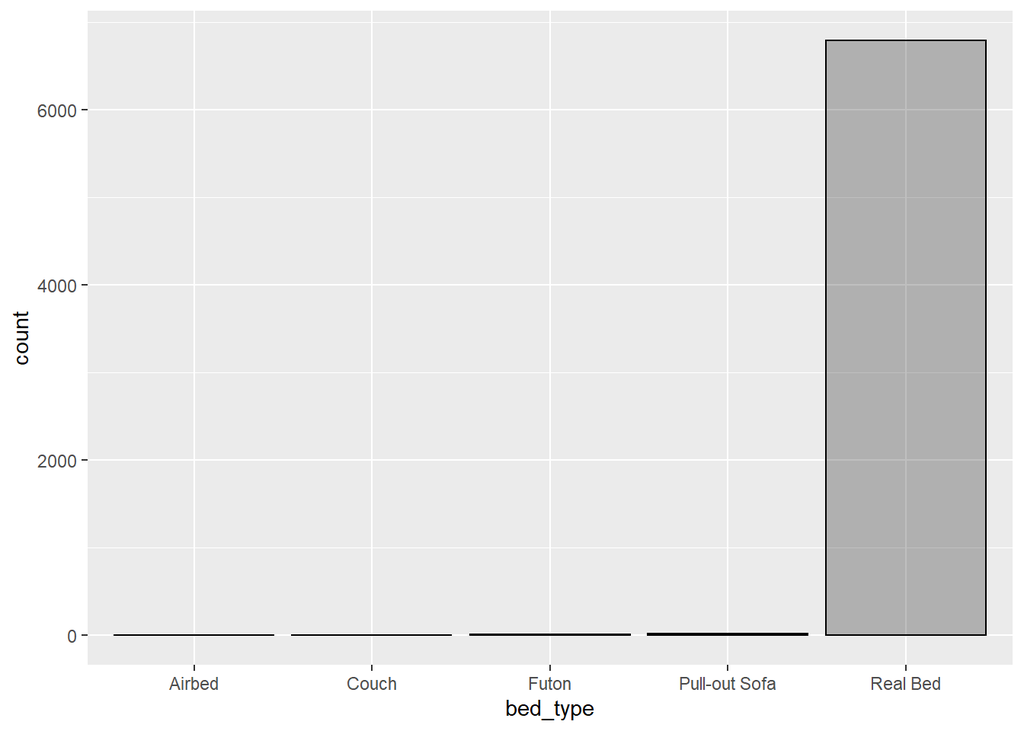

```r
ggplot(listings2, aes(x = bed_type)) +
  geom_bar(fill="black", colour="black", alpha = 0.25)
```

```r
listings2 %>%
  count(bed_type) %>%
  arrange(desc(n))
```

```
##        bed_type    n
## 1      Real Bed 6788
## 2 Pull-out Sofa   23
## 3         Futon   14
## 4        Airbed    4
## 5         Couch    3
```

Only 44 listings have other types of beds instead of real beds. In this empirical project, we only consider real bed.

```r
listings2 <- listings2 %>% filter(bed_type == "Real Bed") %>% dplyr::select(-bed_type)
```

#### 3.2. Property Type

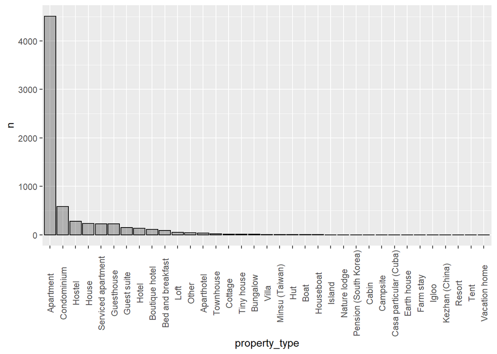

```r
listings2 %>%
    count(property_type) %>%
    mutate(property_type = fct_reorder(property_type, n, .desc = TRUE)) %>%
    ggplot(aes(x = property_type, y = n)) +
  geom_bar(stat = 'identity', fill="black", colour="black", alpha = 0.25) +
  theme(axis.text.x = element_text(angle = 90, vjust = 0.5))
```

```r
property_cnt <- listings2 %>%
  count(property_type) %>%
  arrange(desc(n))
property_cnt
```

```
##             property_type    n
## 1               Apartment 4509
## 2             Condominium  583
## 3                  Hostel  283
## 4                   House  235
## 5      Serviced apartment  226
## 6              Guesthouse  223
## 7             Guest suite  150
## 8                   Hotel  136
## 9          Boutique hotel  115
## 10      Bed and breakfast   87
## 11                   Loft   52
## 12                  Other   45
## 13             Aparthotel   39
## 14              Townhouse   23
```

[output cut: 21 more lines]

```r
listings2 <- listings2 %>%
  merge(property_cnt, by = "property_type") %>%
  mutate(property_type = case_when(
    n > 50 ~ property_type,
    TRUE ~ "other_property_types"
  )) %>%
  dplyr::select(-n)
```

#### 3.3. Year

```r
paste("The earliest year of host_since is ",min(listings$host_since),", and the lastest year of host_since is ",max(listings$host_since),sep='')
```

```
## [1] "The earliest year of host_since is NA, and the lastest year of host_since is NA"
```

```r
paste("The earliest year of first_review is ",min(listings$first_review),", and the lastest year of first_review is ",max(listings$first_review),sep='')
```

```
## [1] "The earliest year of first_review is NA, and the lastest year of first_review is NA"
```

```r
paste("The earliest year of last_review is ",min(listings$last_review),", and the lastest year of last_review is ",max(listings$last_review),sep='')
```

```
## [1] "The earliest year of last_review is NA, and the lastest year of last_review is NA"
```

#### 3.4. Scores correlation matrix

The empirical project is interested in the order of importance of these six dimensions. To see their correlations, a correlation matrix is created.

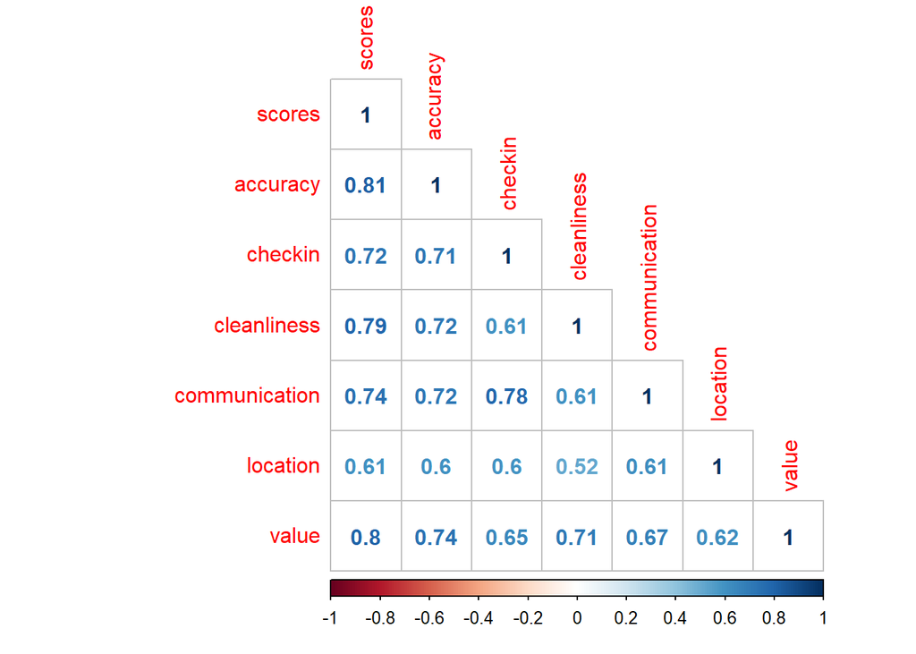

```r
listings_scores <- listings2 %>%
  dplyr::select(review_scores_rating,
         review_scores_accuracy,
         review_scores_checkin,
         review_scores_cleanliness,
         review_scores_communication,
         review_scores_location,
         review_scores_value) %>%
  rename(scores = review_scores_rating,
         accuracy = review_scores_accuracy,
         checkin = review_scores_checkin,
         cleanliness = review_scores_cleanliness,
         communication = review_scores_communication,
         location = review_scores_location,
         value = review_scores_value)
corrplot(cor(listings_scores), type = "lower", method = "number")
```

Accuracy, value, and cleanliness are the three most important dimensions, with correlations separately in 0.81, 0.80, and 0.79. However, location has a comparatively weak correlation with review scores rating, which is 0.61.

#### 3.5. CX scores

`review_scores_rating` is an overall score on the AirBnb listing from 0 to 100. `reviews_per_month` is the number of reviews received by a listing per month.

##### 3.5.1. review_scores_rating

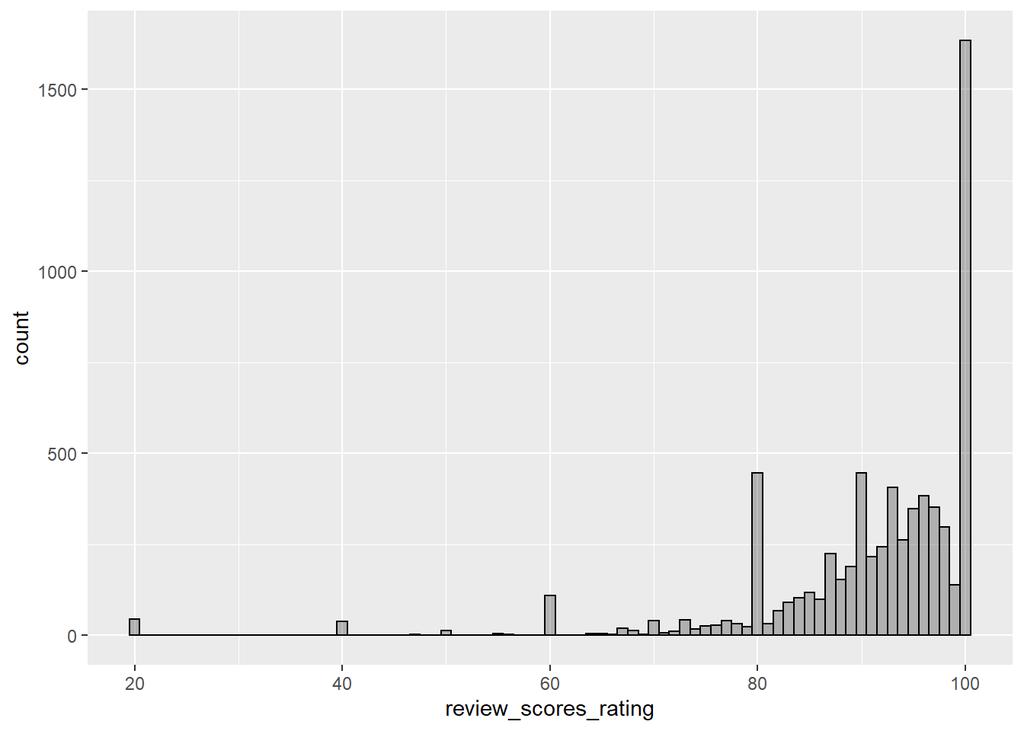

```r
ggplot(listings2, aes(x = review_scores_rating)) +
  geom_histogram(fill="black", colour="black", alpha = 0.25, binwidth=1)
```

- maximum and minimum

```r
min(listings2$review_scores_rating)
```

```
## [1] 20
```

```r
max(listings2$review_scores_rating)
```

```
## [1] 100
```

- skewness

```r
skewness(listings2$review_scores_rating)
```

```
## [1] -2.861506
```

- kurtosis

```r
kurtosis(listings2$review_scores_rating)
```

```
## [1] 12.31641
```

##### 3.5.2. reviews_per_month

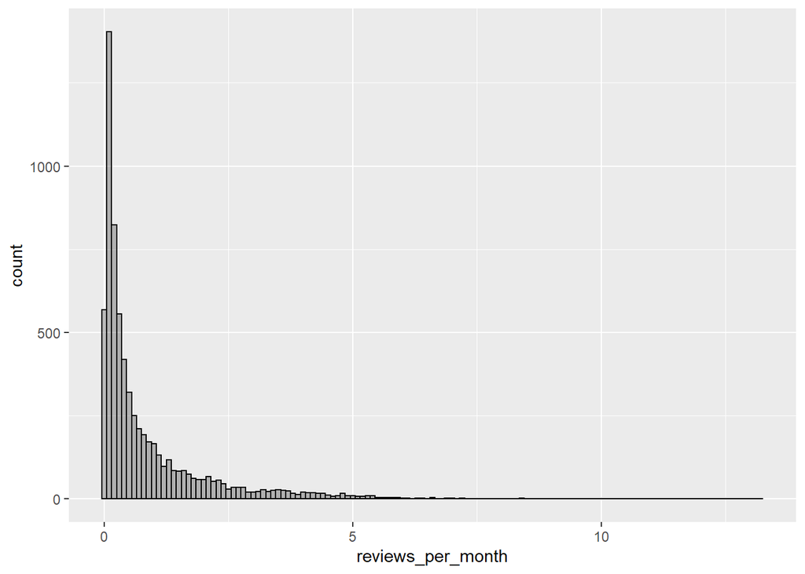

```r
ggplot(listings2, aes(x = reviews_per_month)) +
  geom_histogram(fill="black", colour="black", alpha = 0.25, binwidth=0.1)
```

- maximum and minimum

```r
min(listings2$reviews_per_month)
```

```
## [1] 0.01
```

```r
max(listings2$reviews_per_month)
```

```
## [1] 13.23
```

- skewness

```r
skewness(listings2$reviews_per_month)
```

```
## [1] 2.617639
```

- kurtosis

```r
kurtosis(listings2$reviews_per_month)
```

```
## [1] 9.383842
```

##### 3.5.3. cx_scores

We consider a new variable CX scores calculated by simply multiplying together the normalized review scores rating with the number of reviews per month.

Replace `review_scores_rating` with `cx_scores` and drop `review_scores_rating`, `review_scores_accuracy`, `review_scores_checkin`, `review_scores_cleanliness`, `review_scores_communication`,`review_scores_location`, `review_scores_value`, `reviews_per_month`, `number_of_reviews`, `number_of_reviews_ltmh`,

```r
listings3 <- listings2 %>%
  mutate(cx_scores = review_scores_rating/100*reviews_per_month) %>%
  dplyr::select(-review_scores_rating,
         -review_scores_accuracy,
         -review_scores_checkin,
         -review_scores_cleanliness,
         -review_scores_communication,
         -review_scores_location,
         -review_scores_value,
         -reviews_per_month,
         -number_of_reviews,
         -number_of_reviews_ltm)
```

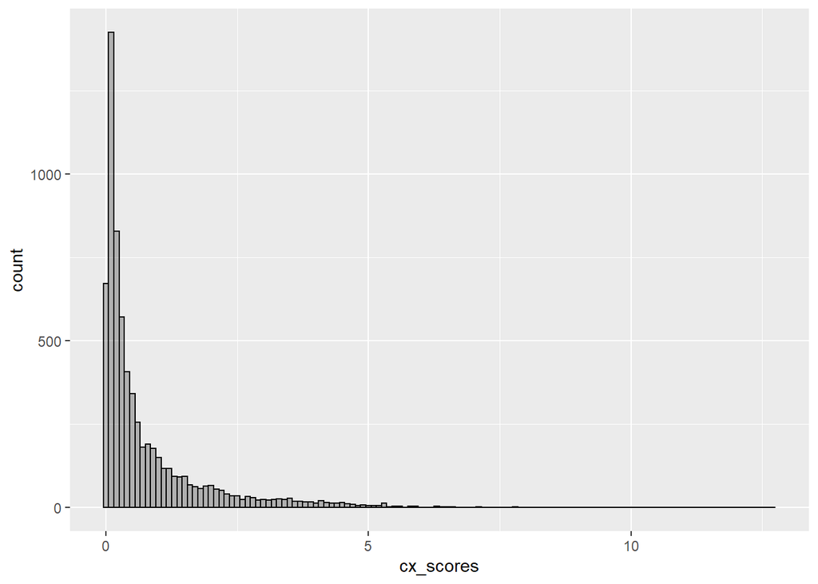

```r
ggplot(listings3, aes(x = cx_scores)) +
  geom_histogram(fill="black", colour="black", alpha = 0.25, binwidth=0.1)
```

- maximum, minimum and quantile

```r
min(listings3$cx_scores)
```

```
## [1] 0.004
```

```r
max(listings3$cx_scores)
```

```
## [1] 12.7008
```

```r
IQR(listings3$cx_scores)
```

```
## [1] 0.87285
```

```r
quantile(listings3$cx_scores)
```

```
##       0%      25%      50%      75%     100%
##  0.00400  0.11695  0.33320  0.98980 12.70080
```

- remove outliers

```r
# Identify outliers
outliers <- boxplot(listings3$cx_scores, plot = FALSE)$out
# Remove outliers
listings3 <- listings3[!(listings3$cx_scores %in% outliers), ]
# Quantile
quantile(listings3$cx_scores)
```

```
##       0%      25%      50%      75%     100%
## 0.004000 0.104625 0.276600 0.717225 2.298900
```

#### 3.6. Data skimming

```r
skim(listings3)
```

Data summary

| Name | listings3 |
| --- | --- |
| Number of rows | 6166 |
| Number of columns | 41 |
| _______________________ |  |
| Column type frequency: |  |
| character | 6 |
| numeric | 35 |
| ________________________ |  |
| Group variables | None |

**Variable type: character**

| skim_variable | n_missing | complete_rate | min | max | empty | n_unique | whitespace |
| --- | --- | --- | --- | --- | --- | --- | --- |
| property_type | 0 | 1 | 4 | 20 | 0 | 12 | 0 |
| host_response_time | 0 | 1 | 11 | 18 | 0 | 5 | 0 |
| host_verifications | 0 | 1 | 2 | 156 | 0 | 219 | 0 |
| neighbourhood_cleansed | 0 | 1 | 5 | 17 | 0 | 18 | 0 |
| room_type | 0 | 1 | 10 | 15 | 0 | 4 | 0 |
| amenities | 0 | 1 | 2 | 1128 | 0 | 5274 | 0 |

**Variable type: numeric**

| skim_variable | n_missing | complete_rate | mean | sd | p0 | p25 | p50 | p75 | p100 | hist |
| --- | --- | --- | --- | --- | --- | --- | --- | --- | --- | --- |
| id | 0 | 1 | 21665699.10 | 10946047.74 | 69074 | 13049061.8 | 22037233.50 | 30840039.75 | 43692479.0 | ▅▆▇▇▃ |
| host_response_rate | 0 | 1 | 0.49 | 0.47 | 0 | 0.0 | 0.56 | 1.00 | 1.0 | ▇▁▁▁▇ |
| host_acceptance_rate | 0 | 1 | 0.62 | 0.45 | 0 | 0.0 | 0.91 | 1.00 | 1.0 | ▅▁▁▁▇ |
| host_is_superhost | 0 | 1 | 0.14 | 0.34 | 0 | 0.0 | 0.00 | 0.00 | 1.0 | ▇▁▁▁▁ |
| host_has_profile_pic | 0 | 1 | 1.00 | 0.07 | 0 | 1.0 | 1.00 | 1.00 | 1.0 | ▁▁▁▁▇ |
| host_identity_verified | 0 | 1 | 0.34 | 0.47 | 0 | 0.0 | 0.00 | 1.00 | 1.0 | ▇▁▁▁▅ |
| accommodates | 0 | 1 | 3.01 | 2.17 | 1 | 2.0 | 2.00 | 4.00 | 16.0 | ▇▁▁▁▁ |
| bathrooms | 0 | 1 | 1.16 | 0.56 | 0 | 1.0 | 1.00 | 1.00 | 11.0 | ▇▁▁▁▁ |
| bedrooms | 0 | 1 | 1.12 | 0.84 | 0 | 1.0 | 1.00 | 1.00 | 11.0 | ▇▁▁▁▁ |
| beds | 0 | 1 | 1.78 | 1.47 | 0 | 1.0 | 1.00 | 2.00 | 19.0 | ▇▁▁▁▁ |
| price | 0 | 1 | 734.43 | 1356.09 | 0 | 349.0 | 504.00 | 822.00 | 66667.0 | ▇▁▁▁▁ |
| weekly_price | 0 | 1 | 5048.46 | 8904.01 | 0 | 2387.0 | 3528.00 | 5631.50 | 466669.0 | ▇▁▁▁▁ |
| monthly_price | 0 | 1 | 21380.84 | 37967.61 | 0 | 9990.0 | 15120.00 | 23940.00 | 2000010.0 | ▇▁▁▁▁ |
| security_deposit | 0 | 1 | 1438.72 | 2726.02 | 0 | 219.0 | 1387.00 | 1387.00 | 39235.0 | ▇▁▁▁▁ |
| cleaning_fee | 0 | 1 | 177.43 | 177.85 | 0 | 88.0 | 175.00 | 200.00 | 4682.0 | ▇▁▁▁▁ |
| guests_included | 0 | 1 | 1.52 | 1.17 | 1 | 1.0 | 1.00 | 2.00 | 16.0 | ▇▁▁▁▁ |
| extra_people | 0 | 1 | 76.42 | 165.18 | 0 | 0.0 | 0.00 | 100.00 | 2300.0 | ▇▁▁▁▁ |
| minimum_nights | 0 | 1 | 6.01 | 26.41 | 1 | 1.0 | 1.00 | 3.00 | 1000.0 | ▇▁▁▁▁ |
| maximum_nights | 0 | 1 | 698983.06 | 38673167.24 | 1 | 180.0 | 1125.00 | 1125.00 | 2147483647.0 | ▇▁▁▁▁ |
| minimum_minimum_nights | 0 | 1 | 5.89 | 26.36 | 1 | 1.0 | 1.00 | 3.00 | 1000.0 | ▇▁▁▁▁ |
| maximum_minimum_nights | 0 | 1 | 6.31 | 27.68 | 1 | 1.0 | 2.00 | 3.00 | 1000.0 | ▇▁▁▁▁ |
| minimum_maximum_nights | 0 | 1 | 699014.93 | 38673166.67 | 1 | 365.0 | 1125.00 | 1125.00 | 2147483647.0 | ▇▁▁▁▁ |
| maximum_maximum_nights | 0 | 1 | 699022.82 | 38673166.53 | 1 | 365.0 | 1125.00 | 1125.00 | 2147483647.0 | ▇▁▁▁▁ |
| minimum_nights_avg_ntm | 0 | 1 | 6.08 | 26.52 | 1 | 1.0 | 1.30 | 3.00 | 1000.0 | ▇▁▁▁▁ |
| maximum_nights_avg_ntm | 0 | 1 | 699019.78 | 38673166.58 | 1 | 365.0 | 1125.00 | 1125.00 | 2147483647.0 | ▇▁▁▁▁ |
| instant_bookable | 0 | 1 | 0.46 | 0.50 | 0 | 0.0 | 0.00 | 1.00 | 1.0 | ▇▁▁▁▇ |
| require_guest_profile_picture | 0 | 1 | 0.01 | 0.10 | 0 | 0.0 | 0.00 | 0.00 | 1.0 | ▇▁▁▁▁ |
| require_guest_phone_verification | 0 | 1 | 0.01 | 0.11 | 0 | 0.0 | 0.00 | 0.00 | 1.0 | ▇▁▁▁▁ |
| calculated_host_listings_count | 0 | 1 | 14.56 | 36.38 | 1 | 1.0 | 3.00 | 14.00 | 389.0 | ▇▁▁▁▁ |
| calculated_host_listings_count_entire_homes | 0 | 1 | 3.43 | 10.62 | 0 | 0.0 | 1.00 | 2.00 | 108.0 | ▇▁▁▁▁ |
| calculated_host_listings_count_private_rooms | 0 | 1 | 9.41 | 30.77 | 0 | 0.0 | 1.00 | 7.00 | 339.0 | ▇▁▁▁▁ |
| calculated_host_listings_count_shared_rooms | 0 | 1 | 1.10 | 6.19 | 0 | 0.0 | 0.00 | 0.00 | 82.0 | ▇▁▁▁▁ |
| last_first_review | 0 | 1 | -1.37 | 1.54 | -9 | -2.0 | -1.00 | 0.00 | 0.0 | ▁▁▁▃▇ |
| host_experience_year | 0 | 1 | 4.67 | 2.04 | 0 | 3.0 | 5.00 | 6.00 | 11.0 | ▃▆▇▃▁ |
| cx_scores | 0 | 1 | 0.50 | 0.54 | 0 | 0.1 | 0.28 | 0.72 | 2.3 | ▇▂▁▁▁ |

#### 3.7. Character variables

- property_type

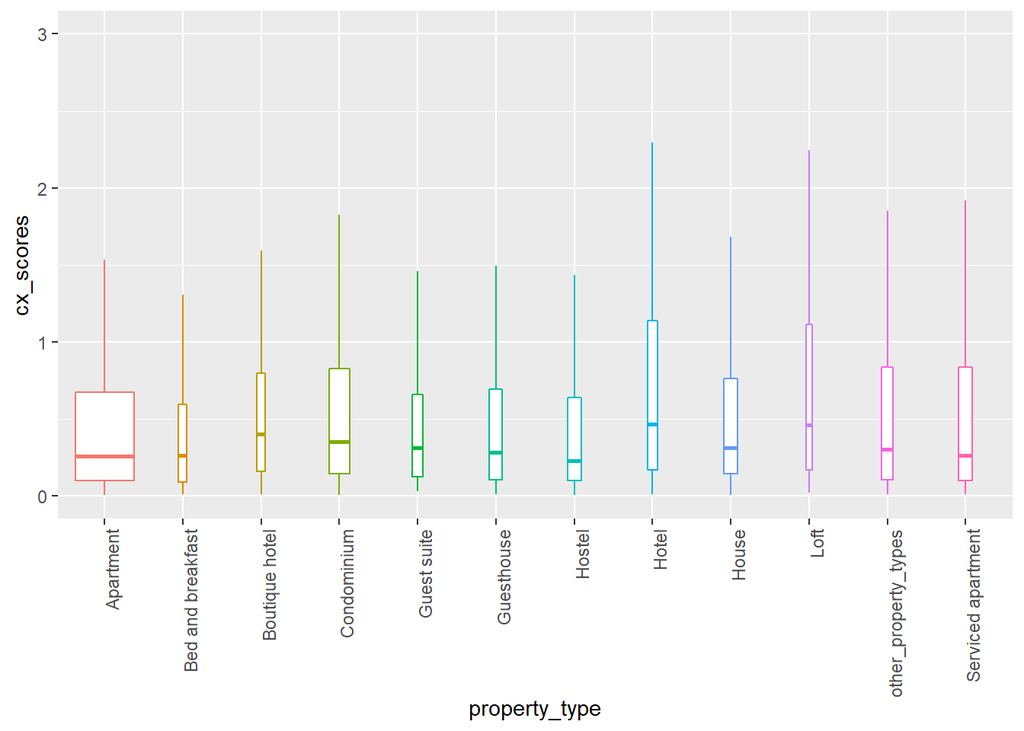

```r
ggplot(data = listings3, aes(x = as.character(property_type), y = cx_scores, color = as.character(property_type))) +
  geom_boxplot(outlier.shape = NA, varwidth = TRUE) +
  theme(axis.text.x = element_text(angle = 90, hjust = 1),legend.position = "none")+
  coord_cartesian(ylim = c(0, 3)) +
  xlab("property_type")
```

- room_type

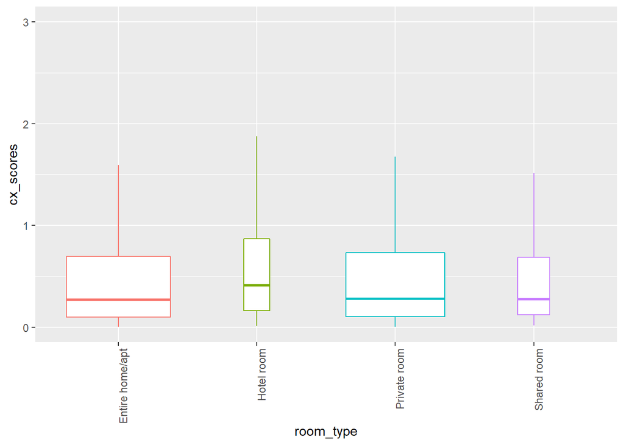

```r
ggplot(data = listings3, aes(x = as.character(room_type), y = cx_scores, color = as.character(room_type))) +
  geom_boxplot(outlier.shape = NA, varwidth = TRUE) +
  theme(axis.text.x = element_text(angle = 90, hjust = 1),legend.position = "none")+
  coord_cartesian(ylim = c(0, 3)) +
  xlab("room_type")
```

- neighbourhood_cleansed

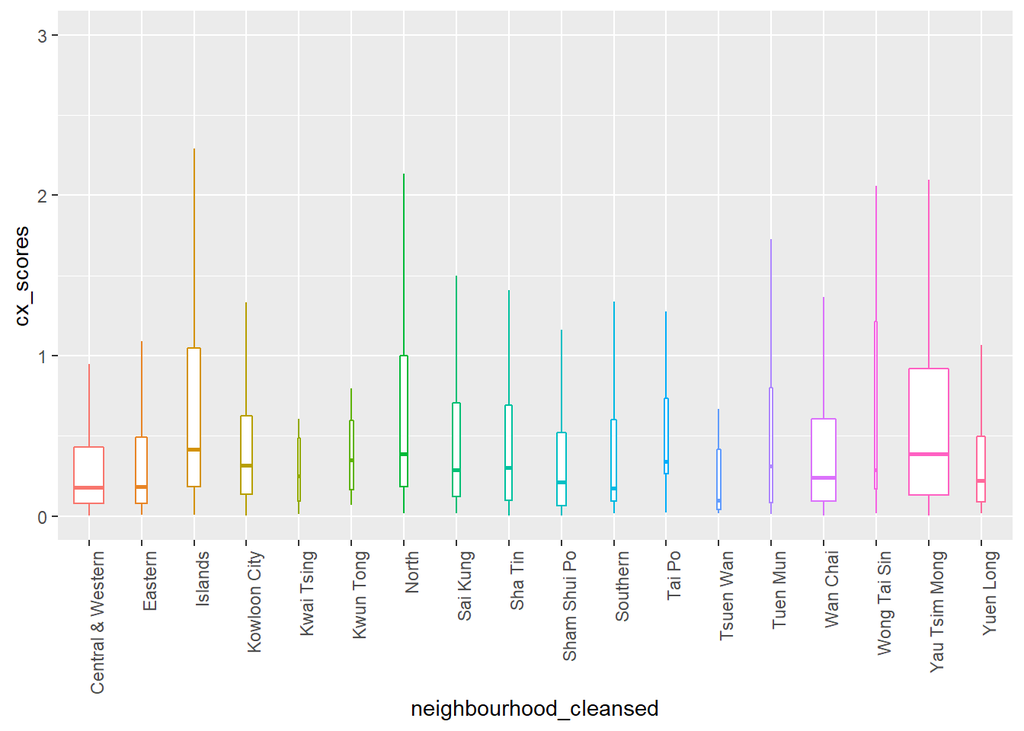

```r
ggplot(data = listings3, aes(x = as.character(neighbourhood_cleansed), y = cx_scores, color = as.character(neighbourhood_cleansed))) +
  geom_boxplot(outlier.shape = NA, varwidth = TRUE) +
  theme(axis.text.x = element_text(angle = 90, hjust = 1),legend.position = "none")+
  coord_cartesian(ylim = c(0, 3)) +
  xlab("neighbourhood_cleansed")
```

- host_response_time

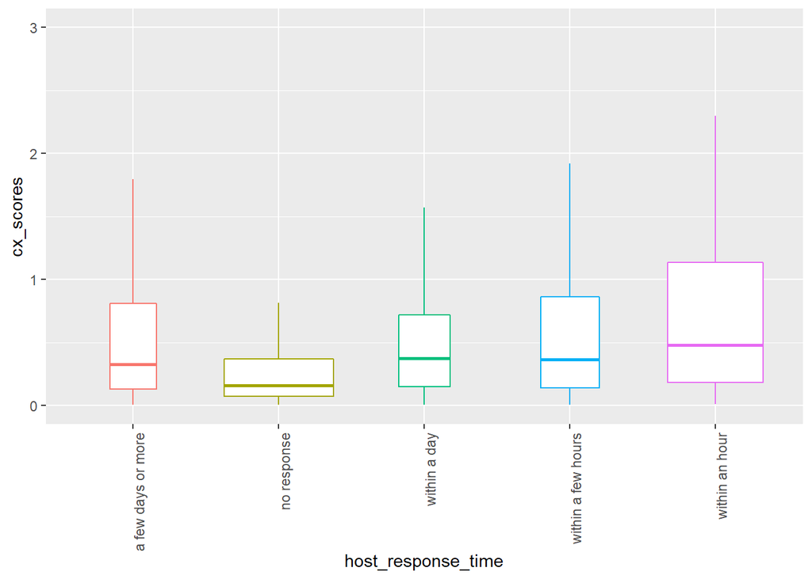

```r
ggplot(data = listings3, aes(x = as.character(host_response_time), y = cx_scores, color = as.character(host_response_time))) +
  geom_boxplot(outlier.shape = NA, varwidth = TRUE) +
  theme(axis.text.x = element_text(angle = 90, hjust = 1),legend.position = "none")+
  coord_cartesian(ylim = c(0, 3)) +
  xlab("host_response_time")
```

#### 3.8. Numeric Variables

Transform character variables into numeric variables

```r
listings4 <- listings3 %>% mutate(val1 = 1, val2 = 1, val3 = 1, val4 = 1, val5 = 1)
listings4 <- listings4 %>%
  spread(host_response_time, val1, fill = 0) %>%
  spread(neighbourhood_cleansed, val2, fill = 0) %>%
  spread(property_type, val3, fill = 0) %>%
  spread(room_type, val4, fill = 0)

listings4 <- listings4 %>% dplyr::select(-id)

names(listings4) <- gsub(" ", "_", names(listings4))
names(listings4) <- gsub("&", "", names(listings4))
names(listings4) <- gsub("/", "_", names(listings4))
names(listings4) <- gsub("__", "_", names(listings4))
```

- host_response_rate

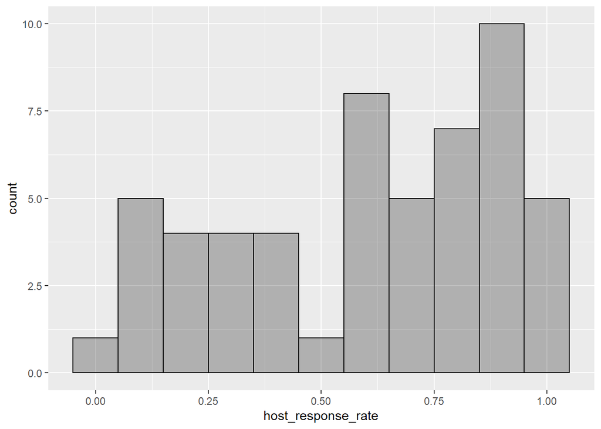

```r
ggplot(listings4 %>% count(host_response_rate), aes(x = host_response_rate)) +
  geom_histogram(fill="black", colour="black", alpha = 0.25, binwidth=0.1)
```

- host_acceptance_rate

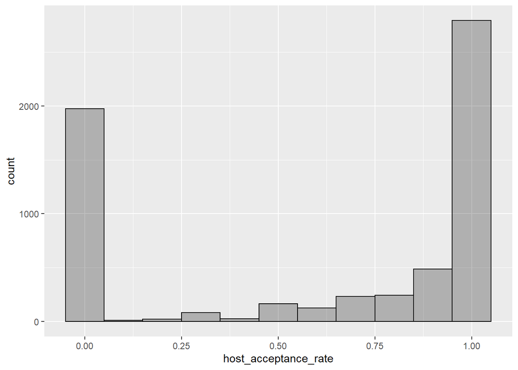

```r
ggplot(listings4, aes(x = host_acceptance_rate)) +
  geom_histogram(fill="black", colour="black", alpha = 0.25, binwidth=0.1)
```

- accommodates

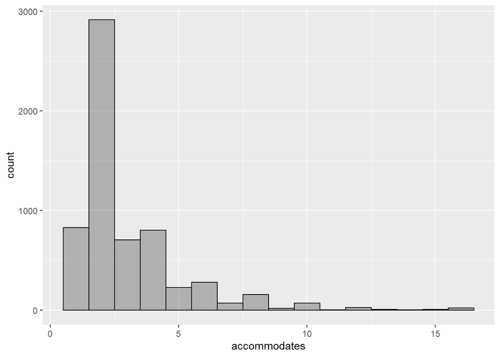

```r
ggplot(listings4, aes(x = accommodates)) +
  geom_histogram(fill="black", colour="black", alpha = 0.25, binwidth=1)
```

- bathrooms

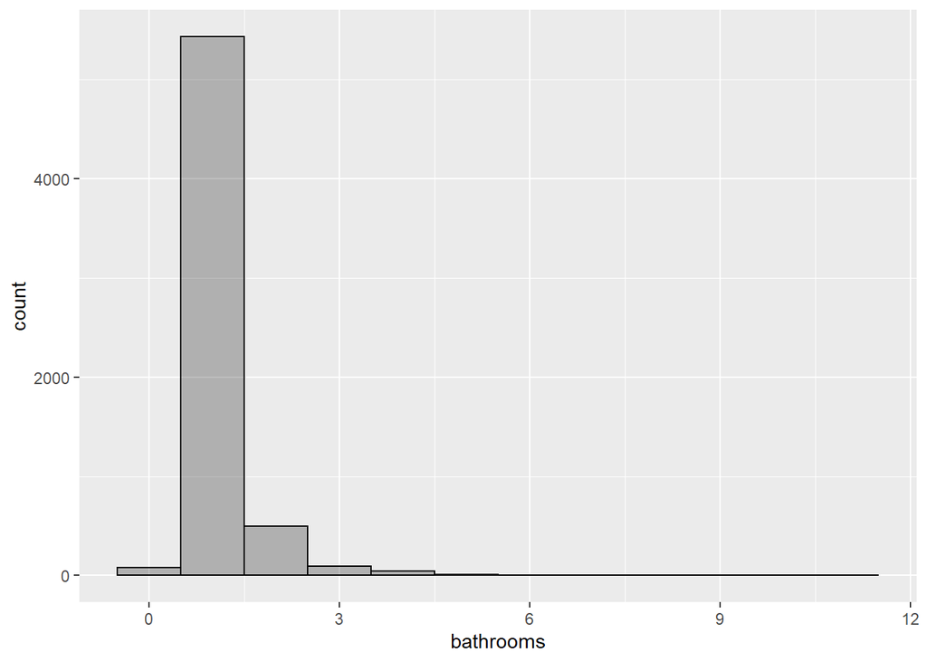

```r
ggplot(listings4, aes(x = bathrooms)) +
  geom_histogram(fill="black", colour="black", alpha = 0.25, binwidth=1)
```

- bedrooms

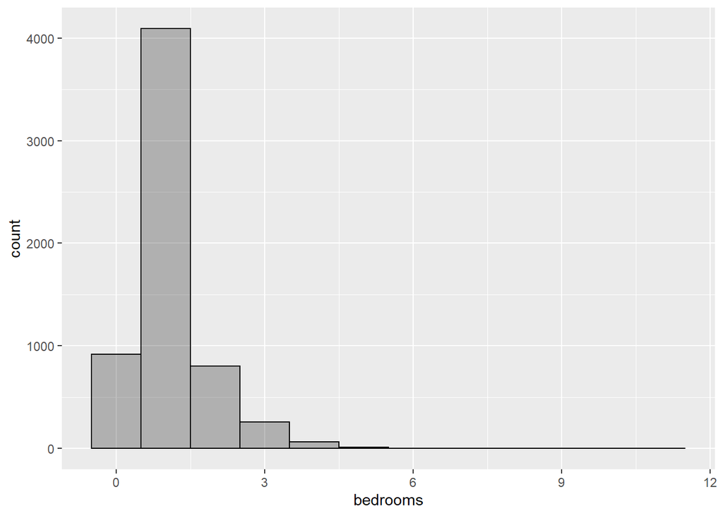

```r
ggplot(listings4, aes(x = bedrooms)) +
  geom_histogram(fill="black", colour="black", alpha = 0.25, binwidth=1)
```

- beds

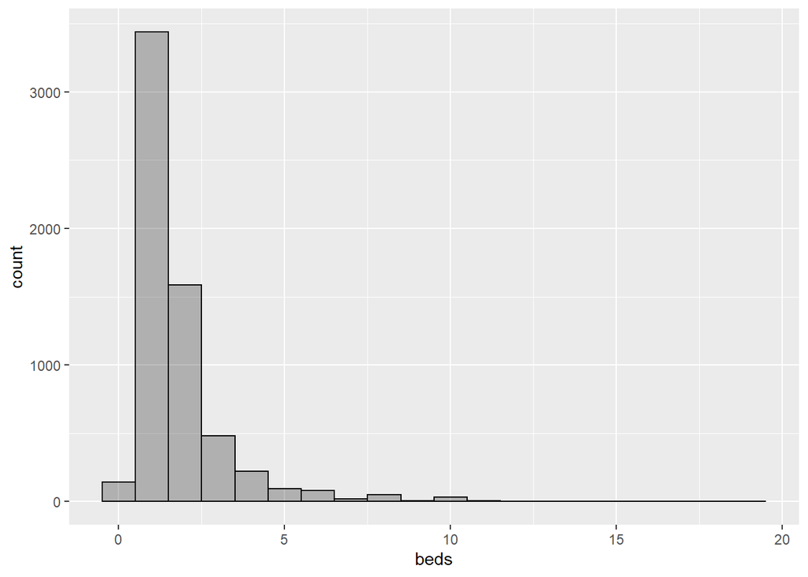

```r
ggplot(listings4, aes(x = beds)) +
  geom_histogram(fill="black", colour="black", alpha = 0.25, binwidth=1)
```

- price

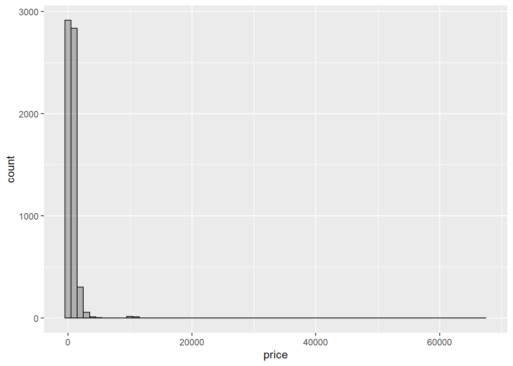

```r
ggplot(listings4, aes(x = price)) +
  geom_histogram(fill="black", colour="black", alpha = 0.25, binwidth=1000)
```

- weekly_price

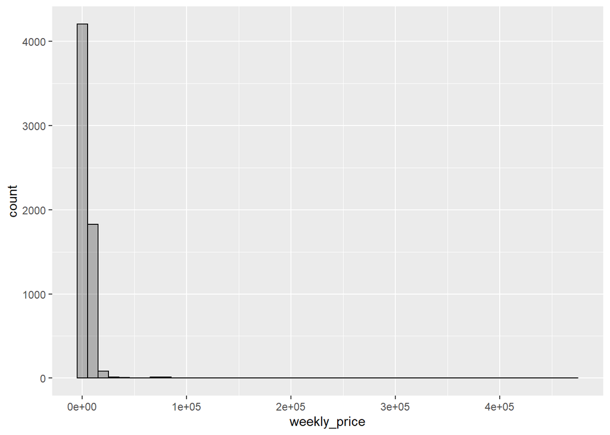

```r
ggplot(listings4, aes(x = weekly_price)) +
  geom_histogram(fill="black", colour="black", alpha = 0.25, binwidth=10000)
```

- monthly_price

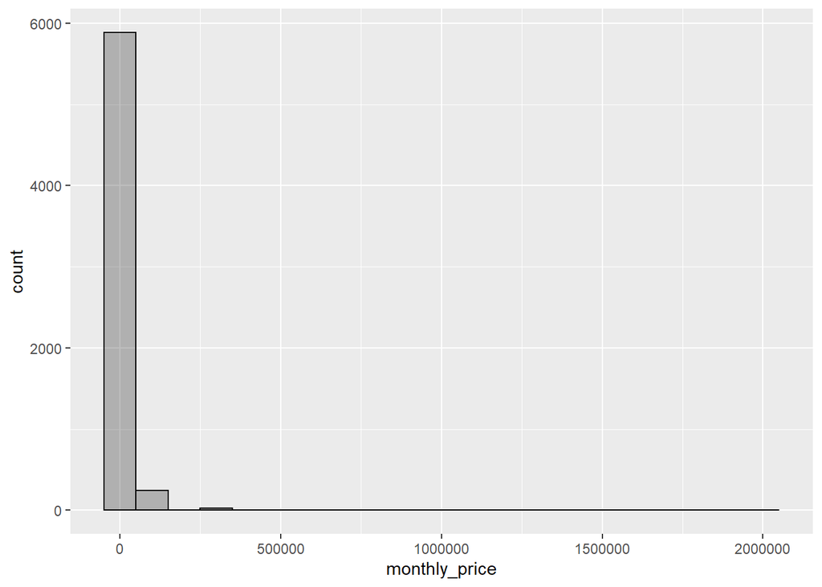

```r
ggplot(listings4, aes(x = monthly_price)) +
  geom_histogram(fill="black", colour="black", alpha = 0.25, binwidth=100000)
```

- calculated_host_listings_count

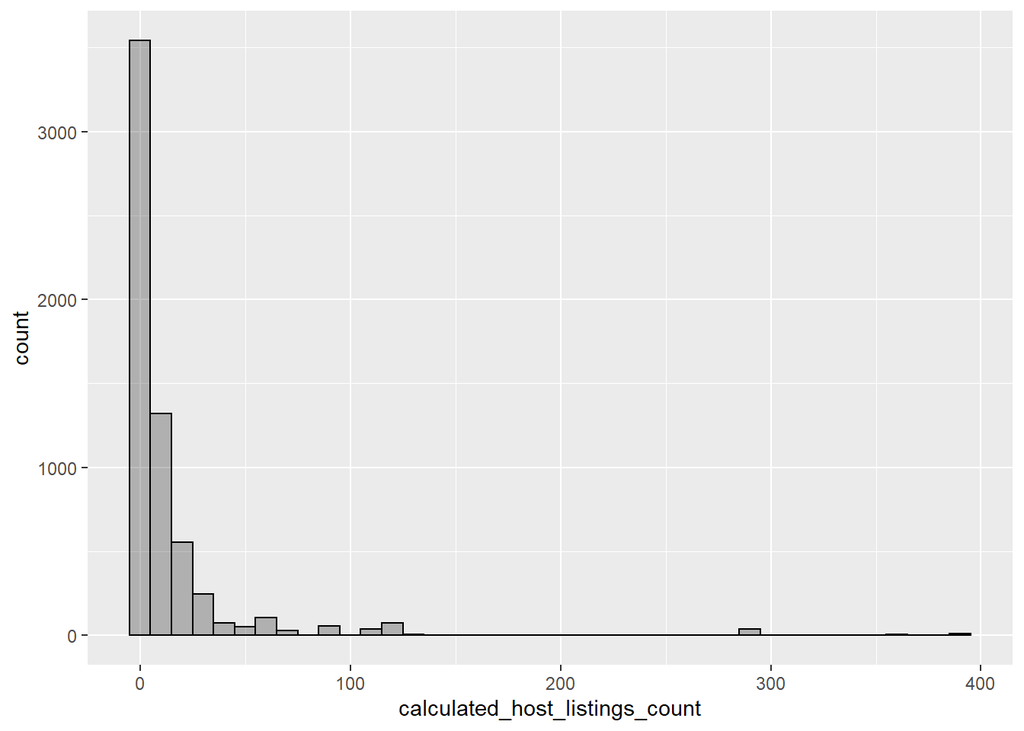

```r
ggplot(listings4, aes(x = calculated_host_listings_count)) +
  geom_histogram(fill="black", colour="black", alpha = 0.25, binwidth=10)
```

- calculated_host_listings_count_entire_homes

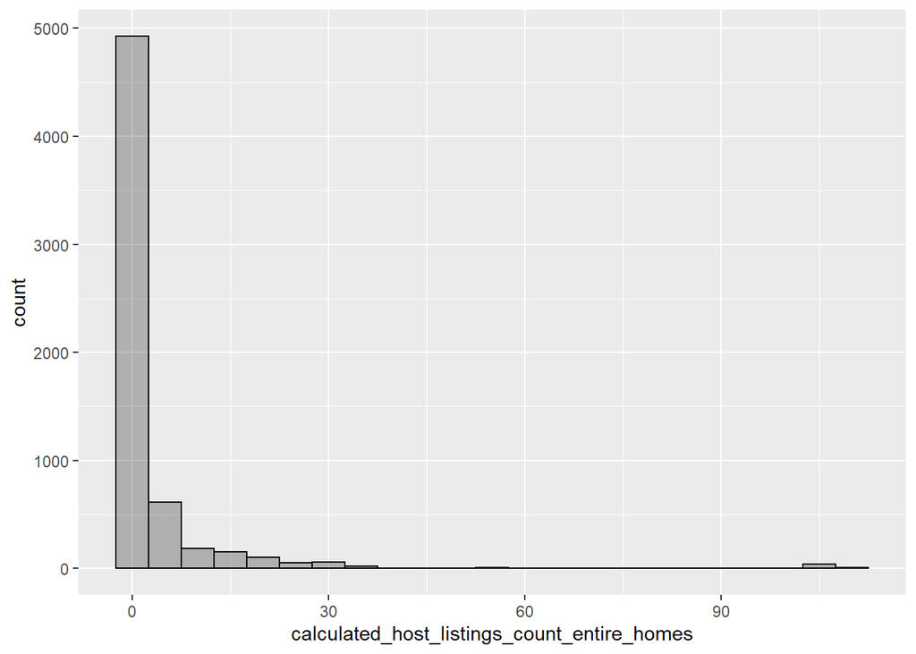

```r
ggplot(listings4, aes(x = calculated_host_listings_count_entire_homes)) +
  geom_histogram(fill="black", colour="black", alpha = 0.25, binwidth=5)
```

- calculated_host_listings_count_private_rooms

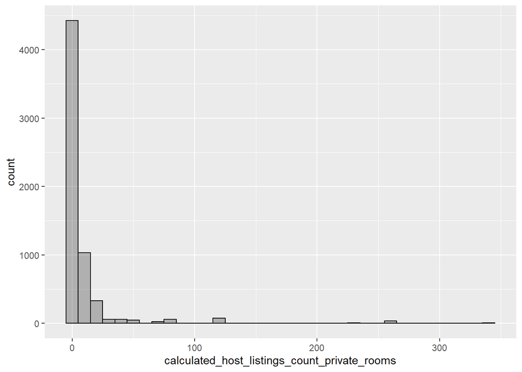

```r
ggplot(listings4, aes(x = calculated_host_listings_count_private_rooms)) +
  geom_histogram(fill="black", colour="black", alpha = 0.25, binwidth=10)
```

- calculated_host_listings_count_shared_rooms

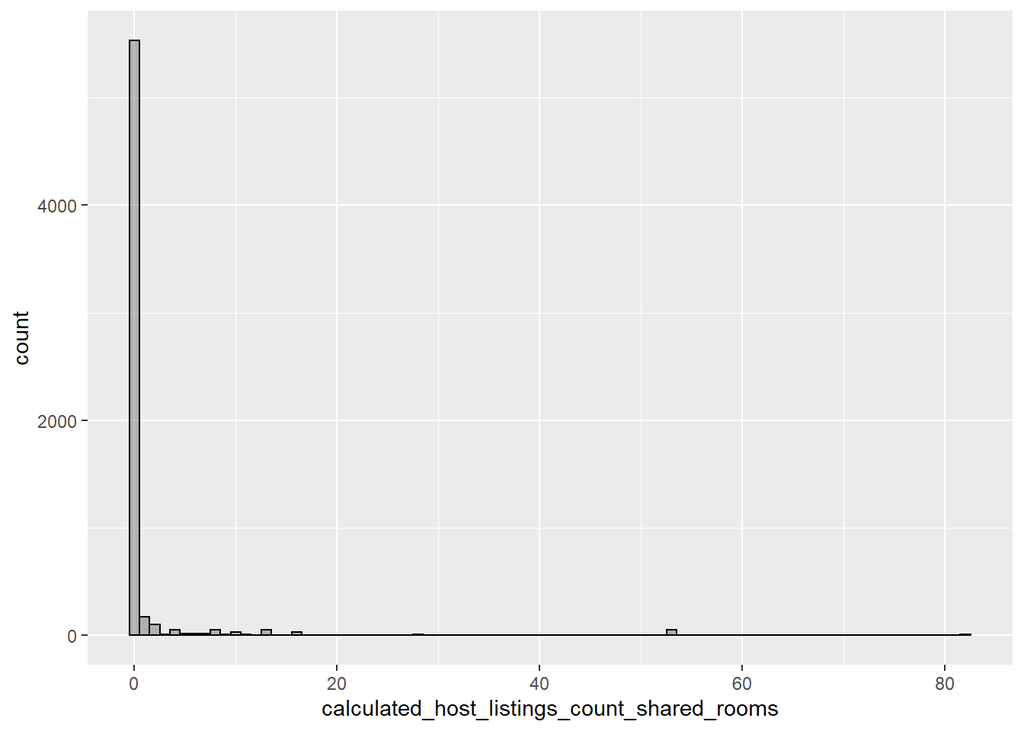

```r
ggplot(listings4, aes(x = calculated_host_listings_count_shared_rooms)) +
  geom_histogram(fill="black", colour="black", alpha = 0.25, binwidth=1)
```

#### 3.9. Amenities & Host_verifications

To transform these two variables into numeric ones, there are two approaches. Firstly, we can simply count the number of amenities and host verifications. Secondly, we can apply natural language processing to see the most popular amenities and host verifications of Airbnb listings in Hong Kong.

##### 3.9.1. Transform by counting

```r
listings_nchar <- listings4 %>%
  mutate(host_verifications = nchar(gsub('[^,]', '', host_verifications))+1,
         amenities = nchar(gsub('[^,]', '', amenities))+1)
```

- The number of host verifications

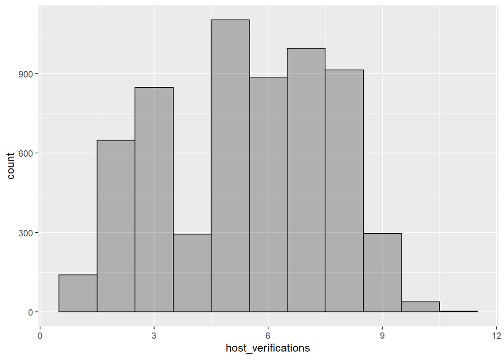

```r
ggplot(listings_nchar, aes(x = host_verifications)) +
  geom_histogram(fill="black", colour="black", alpha = 0.25, binwidth=1)
```

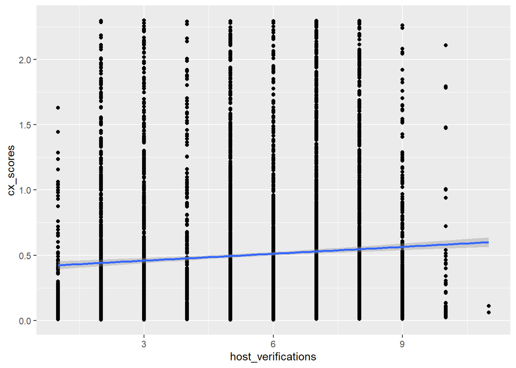

```r
ggplot(data = listings_nchar, aes(x = host_verifications, y = cx_scores)) +
  geom_point() +
  geom_smooth(method = lm)
```

- The number of amenities

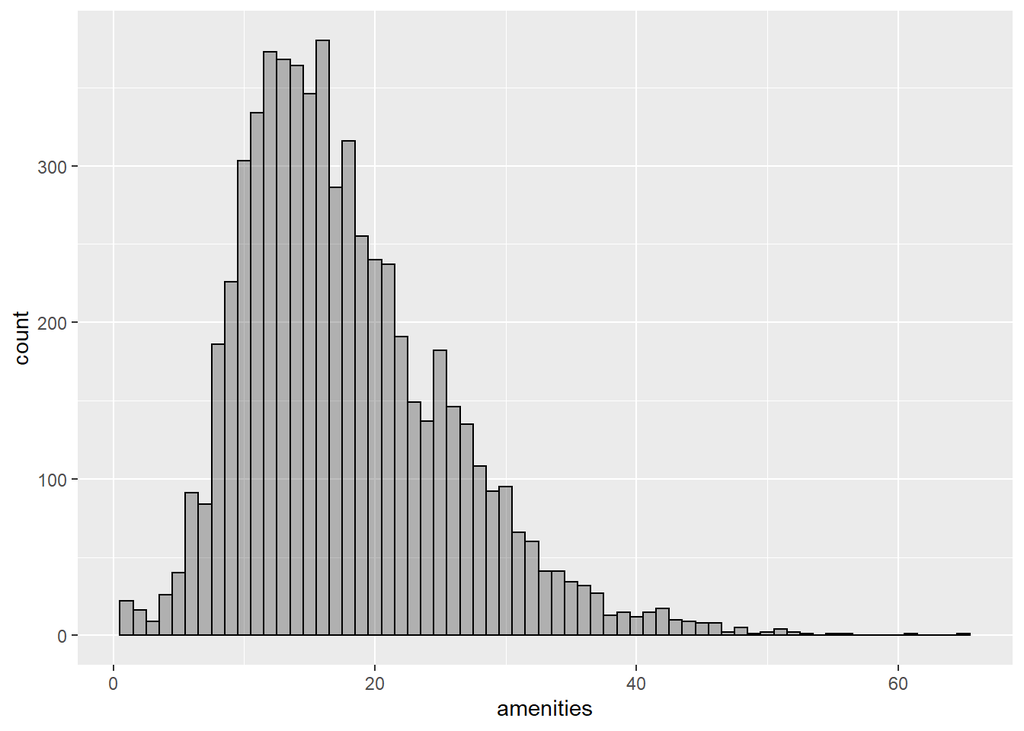

```r
ggplot(listings_nchar, aes(x = amenities)) +
  geom_histogram(fill="black", colour="black", alpha = 0.25, binwidth=1)
```

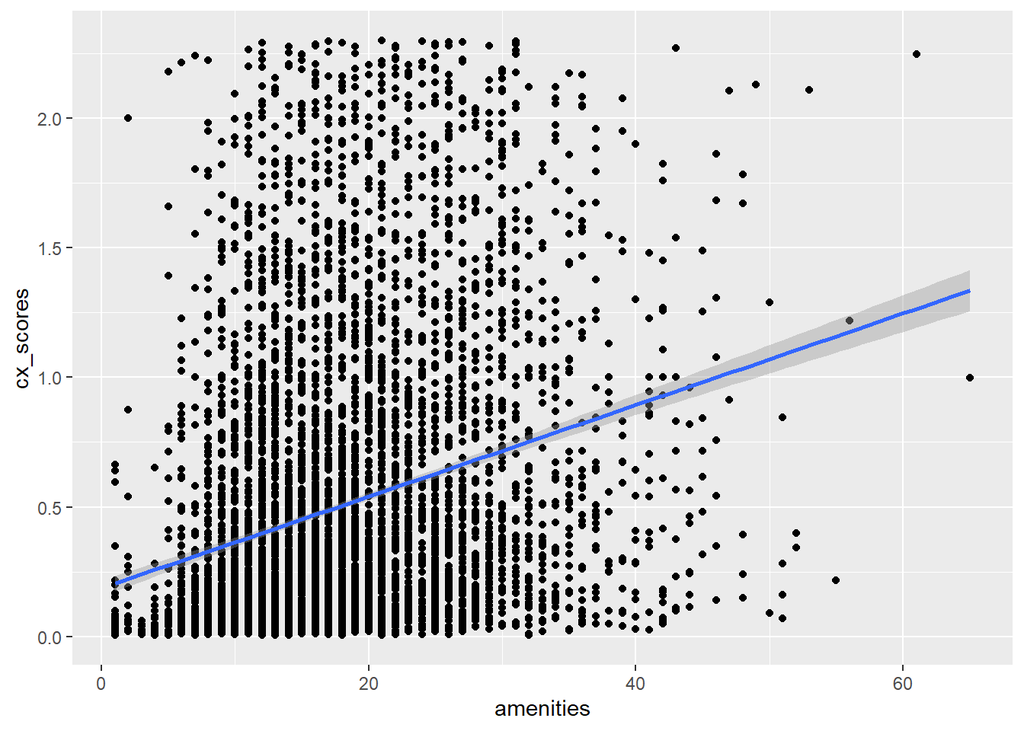

```r
ggplot(data = listings_nchar, aes(x = amenities, y = cx_scores)) +
  geom_point() +
  geom_smooth(method = lm)
```

- Correlation

```r
corr_nchar <- as.data.frame(lapply(listings_nchar, function(x)cor(x, listings_nchar$cx_scores))) %>%
  gather(key = "var", value = "correlation") %>%
  arrange(desc(abs(correlation))) %>%
  filter(abs(correlation) > 0)
corr_nchar
```

```
##                                             var   correlation
## 1                                     cx_scores  1.000000e+00
## 2                             last_first_review -3.876626e-01
## 3                          host_acceptance_rate  3.710438e-01
## 4                                   no_response -2.855346e-01
## 5                            host_response_rate  2.792782e-01
## 6                                     amenities  2.582091e-01
## 7                                within_an_hour  2.503880e-01
## 8                             host_is_superhost  2.047090e-01
## 9                               guests_included  1.789940e-01
## 10                                Yau_Tsim_Mong  1.586342e-01
## 11                              Central_Western -1.560364e-01
## 12                             instant_bookable  1.487605e-01
## 13                                 accommodates  1.155898e-01
## 14                                         beds  8.472833e-02
```

[output cut: 61 more lines]

##### 3.9.2. Transform using NLP

- Amenities

```r
amenities <- listings4 %>% unnest_tokens(word, amenities, token = "regex", pattern = "\\,|\\{|\\}")
frequency_amenities <-  amenities %>% count(word) %>% arrange(desc(n))
head(frequency_amenities,20)
```

```
##                           word    n
## 1           "air conditioning" 6024
## 2                         wifi 5872
## 3                   essentials 5506
## 4                      shampoo 5170
## 5                 "hair dryer" 4794
## 6                           tv 4689
## 7                      hangers 4529
## 8                     elevator 4403
## 9                      kitchen 3806
## 10                      washer 3495
## 11                 "hot water" 3357
## 12 "laptop-friendly workspace" 3316
## 13                        iron 3102
## 14      "lock on bedroom door" 2930
## 15               "smoke alarm" 2898
## 16         "fire extinguisher" 2658
## 17       "family/kid friendly" 2062
## 18                     heating 1887
## 19                refrigerator 1842
## 20   "long term stays allowed" 1675
```

- Host_verifications

```r
host_verifications <- listings4 %>% unnest_tokens(word, host_verifications, token = "regex", pattern = "\\,|\\[|\\]|\\'|\\s")
frequency_host_verifications <-  host_verifications %>% count(word) %>% arrange(desc(n))
head(frequency_host_verifications,10)
```

```
##                     word    n
## 1                  phone 6128
## 2                  email 5695
## 3                reviews 4516
## 4          government_id 4120
## 5                  jumio 4029
## 6  offline_government_id 2566
## 7                 selfie 1892
## 8        identity_manual 1853
## 9               facebook  933
## 10            work_email  553
```

- Spread amenities and host verifications across multiple columns

```r
listings_nlp <- listings4 %>%
  mutate(air_conditioning = case_when(tolower(amenities) %like% '%air conditioning%' ~ 1, TRUE ~ 0),
         wifi = case_when(tolower(amenities) %like% '%wifi%' ~ 1, TRUE ~ 0),
         essentials = case_when(tolower(amenities) %like% '%essentials%' ~ 1, TRUE ~ 0),
         shampoo = case_when(tolower(amenities) %like% '%shampoo%' ~ 1, TRUE ~ 0),
         tv = case_when(tolower(amenities) %like% "%tv,%" ~ 1, TRUE ~ 0),
         hangers = case_when(tolower(amenities) %like% "%hangers%" ~ 1, TRUE ~ 0),
         hair_dryer = case_when(tolower(amenities) %like% "%hair dryer%" ~ 1, TRUE ~ 0),
         elevator = case_when(tolower(amenities) %like% "%elevator%" ~ 1, TRUE ~ 0),
         kitchen = case_when(tolower(amenities) %like% "%kitchen%" ~ 1, TRUE ~ 0),
         hot_water = case_when(tolower(amenities) %like% "%hot water%" ~ 1, TRUE ~ 0),
         washer = case_when(tolower(amenities) %like% '%washer%' ~ 1, TRUE ~ 0),
         laptop_friendly_workspace = case_when(tolower(amenities) %like% '%laptop-friendly workspace%' ~ 1, TRUE ~ 0),
         family_kid_friendly = case_when(tolower(amenities) %like% '%family/kid friendly%' ~ 1, TRUE ~ 0),
         iron = case_when(tolower(amenities) %like% '%iron%' ~ 1, TRUE ~ 0),
         lock_on_bedroom_door = case_when(tolower(amenities) %like% "%lock on bedroom door%" ~ 1, TRUE ~ 0),
         smoke_alarm = case_when(tolower(amenities) %like% "%smoke alarm%" ~ 1, TRUE ~ 0),
         fire_extinguisher = case_when(tolower(amenities) %like% "%fire extinguisher%" ~ 1, TRUE ~ 0),
         refrigerator = case_when(tolower(amenities) %like% "%refrigerator%" ~ 1, TRUE ~ 0),
         heating = case_when(tolower(amenities) %like% "%heating%" ~ 1, TRUE ~ 0),
         long_term_stays_allowed = case_when(tolower(amenities) %like% "%long term stays allowed%" ~ 1, TRUE ~ 0),
         phone = case_when(tolower(host_verifications) %like% "%'phone'%" ~ 1, TRUE ~ 0),
         email = case_when(tolower(host_verifications) %like% "%'email'%" ~ 1, TRUE ~ 0),
         reviews = case_when(tolower(host_verifications) %like% "%'reviews'%" ~ 1, TRUE ~ 0),
         government_id = case_when(tolower(host_verifications) %like% "%'government_id'%" ~ 1, TRUE ~ 0),
         jumio = case_when(tolower(host_verifications) %like% "%'jumio'%" ~ 1, TRUE ~ 0),
         offline_government_id = case_when(tolower(host_verifications) %like% "%'offline_government_id'%" ~ 1, TRUE ~ 0),
         selfie = case_when(tolower(host_verifications) %like% "%'selfie'%" ~ 1, TRUE ~ 0),
         identity_manual = case_when(tolower(host_verifications) %like% "%'identity_manual'%" ~ 1, TRUE ~ 0),
         facebook = case_when(tolower(host_verifications) %like% "%'facebook'%" ~ 1, TRUE ~ 0),
         work_email = case_when(tolower(host_verifications) %like% "%'work_email'%" ~ 1, TRUE ~ 0)) %>%
  dplyr::select(-amenities, -host_verifications)

names(listings_nlp) <- gsub(" ", "_", names(listings_nlp))
names(listings_nlp) <- gsub("&", "", names(listings_nlp))
```

- Correlation

```r
corr_nlp <- as.data.frame(lapply(listings_nlp, function(x)cor(x, listings_nlp$cx_scores))) %>%
  gather(key = "var", value = "correlation") %>%
  arrange(desc(abs(correlation))) %>%
  filter(abs(correlation) > 0)
corr_nlp
```

```
##                                              var   correlation
## 1                                      cx_scores  1.000000e+00
## 2                              last_first_review -3.876626e-01
## 3                           host_acceptance_rate  3.710438e-01
## 4                                    no_response -2.855346e-01
## 5                             host_response_rate  2.792782e-01
## 6                                 within_an_hour  2.503880e-01
## 7                        long_term_stays_allowed  2.321498e-01
## 8                                      hot_water  2.319329e-01
## 9                                   refrigerator  2.253960e-01
## 10                             host_is_superhost  2.047090e-01
## 11                                    hair_dryer  1.983567e-01
## 12                                       shampoo  1.860263e-01
## 13                               guests_included  1.789940e-01
## 14                                 Yau_Tsim_Mong  1.586342e-01
```

[output cut: 89 more lines]

### 4. Summary Statistics

#### 4.1. Normalization

```r
numeric_var_nchar <- c("host_response_rate","host_acceptance_rate","accommodates","bathrooms","bedrooms","beds","price","weekly_price","monthly_price","security_deposit","cleaning_fee","guests_included","extra_people","minimum_nights","maximum_nights","minimum_minimum_nights","maximum_minimum_nights","minimum_maximum_nights","maximum_maximum_nights","minimum_nights_avg_ntm","maximum_nights_avg_ntm","calculated_host_listings_count","calculated_host_listings_count_entire_homes","calculated_host_listings_count_private_rooms","calculated_host_listings_count_shared_rooms","amenities","host_verifications","last_first_review")
for (var in numeric_var_nchar){
    text <- paste("listings_nchar$",var," <- normalize(listings_nchar$",var,",method='standardize')" ,sep='')
  eval(parse(text= text))
}
listings_nchar$cx_scores <- normalize(listings_nchar$cx_scores,method='center')
```

```r
numeric_var_nlp <- c("host_response_rate","host_acceptance_rate","accommodates","bathrooms","bedrooms","beds","price","weekly_price","monthly_price","security_deposit","cleaning_fee","guests_included","extra_people","minimum_nights","maximum_nights","minimum_minimum_nights","maximum_minimum_nights","minimum_maximum_nights","maximum_maximum_nights","minimum_nights_avg_ntm","maximum_nights_avg_ntm","calculated_host_listings_count","calculated_host_listings_count_entire_homes","calculated_host_listings_count_private_rooms","calculated_host_listings_count_shared_rooms","last_first_review")
for (var in numeric_var_nlp){
    text <- paste("listings_nlp$",var," <- normalize(listings_nlp$",var,",method='standardize')" ,sep='')
  eval(parse(text= text))
}
listings_nlp$cx_scores <- normalize(listings_nlp$cx_scores,method='center')
```

The next step is to drop insignificant variables from the regression models.

#### 4.2. Transform by counting

```r
# Remove insignificant variables
fit_nchar_ini <- lm(cx_scores~., listings_nchar)
sig_nchar <- summary(fit_nchar_ini)$coeff[-1,4] < 0.05
sig_nchar <- names(sig_nchar)[sig_nchar == TRUE]
sig_formula_nchar <- as.formula(paste("cx_scores ~",paste(sig_nchar, collapse= "+")))
# Linear Regression Model
fit_nchar <- lm(sig_formula_nchar, listings_nchar)
summary(fit_nchar)
```

```
##
## Call:
## lm(formula = sig_formula_nchar, data = listings_nchar)
##
## Residuals:
##      Min       1Q   Median       3Q      Max
## -1.12377 -0.27469 -0.07106  0.15962  2.03603
##
## Coefficients:
##                                              Estimate Std. Error t value
## (Intercept)                                  0.032743   0.027942   1.172
## host_acceptance_rate                         0.090022   0.007833  11.492
## host_is_superhost                            0.166899   0.017551   9.509
## host_verifications                           0.022584   0.005973   3.781
## host_identity_verified                      -0.028161   0.013146  -2.142
## bathrooms                                   -0.023244   0.006469  -3.593
## bedrooms                                    -0.014918   0.006909  -2.159
## amenities                                    0.081542   0.006348  12.845
## security_deposit                            -0.040085   0.005818  -6.890
## guests_included                              0.052077   0.006431   8.098
## extra_people                                -0.027267   0.006092  -4.476
## minimum_minimum_nights                      -0.010242   0.005823  -1.759
## instant_bookable                             0.089601   0.012903   6.944
## require_guest_profile_picture               -0.127178   0.057710  -2.204
## calculated_host_listings_count_entire_homes -0.033137   0.006126  -5.410
## last_first_review                           -0.192762   0.006537 -29.489
## host_experience_year                        -0.031375   0.003380  -9.282
## no_response                                 -0.071439   0.016649  -4.291
## within_a_day                                -0.090234   0.021817  -4.136
## within_a_few_hours                          -0.052208   0.019460  -2.683
## Central_Western                              0.075334   0.024486   3.077
## Islands                                      0.180464   0.033547   5.380
## Kowloon_City                                 0.064578   0.036578   1.765
## Kwun_Tong                                    0.290534   0.101829   2.853
## North                                        0.079247   0.051680   1.533
## Sha_Tin                                      0.092861   0.056338   1.648
## Sham_Shui_Po                                 0.105018   0.045178   2.325
## Southern                                     0.085231   0.063235   1.348
## Tuen_Mun                                     0.216921   0.107177   2.024
## Wan_Chai                                     0.111996   0.025631   4.369
```

[output cut: 32 more lines]

```
## Sham_Shui_Po                                0.020131 *
## Southern                                    0.177753
## Tuen_Mun                                    0.043019 *
## Wan_Chai                                    1.27e-05 ***
## Yau_Tsim_Mong                               1.94e-08 ***
## Bed_and_breakfast                           0.000363 ***
## Condominium                                 0.157609
## Loft                                        0.003475 **
## Hotel_room                                  0.073914 .
## ---
## Signif. codes:  0 '***' 0.001 '**' 0.01 '*' 0.05 '.' 0.1 ' ' 1
##
## Residual standard error: 0.4443 on 6131 degrees of freedom
## Multiple R-squared:  0.3355, Adjusted R-squared:  0.3318
## F-statistic: 91.05 on 34 and 6131 DF,  p-value: < 2.2e-16
```

Further reduce dimensionality by removing insignificant variables

```r
# Summary Statistics
listings_reg_nchar <- listings_nchar[,append("cx_scores",sig_nchar)] %>%
  dplyr::select(-minimum_minimum_nights,-Kowloon_City,-North,-Sha_Tin,-Southern,-Condominium,-Hotel_room)
stargazer(listings_reg_nchar,type='html',title = 'Summary Statistics',nobs = FALSE,out = 'summary_statistics_nchar.html')
```

```r
summary(listings_reg_nchar)
```

```
##    cx_scores       host_acceptance_rate host_is_superhost host_verifications
##  Min.   :-0.4971   Min.   :-1.3822      Min.   :0.0000    Min.   :-2.0097
##  1st Qu.:-0.3965   1st Qu.:-1.3822      1st Qu.:0.0000    1st Qu.:-1.0978
##  Median :-0.2245   Median : 0.6626      Median :0.0000    Median : 0.2700
##  Mean   : 0.0000   Mean   : 0.0000      Mean   :0.1377    Mean   : 0.0000
##  3rd Qu.: 0.2161   3rd Qu.: 0.8649      3rd Qu.:0.0000    3rd Qu.: 0.7259
##  Max.   : 1.7978   Max.   : 0.8649      Max.   :1.0000    Max.   : 2.5496
##  host_identity_verified   bathrooms          bedrooms         amenities
##  Min.   :0.0000         Min.   :-2.0869   Min.   :-1.3453   Min.   :-2.1098
##  1st Qu.:0.0000         1st Qu.:-0.2928   1st Qu.:-0.1492   1st Qu.:-0.7259
##  Median :0.0000         Median :-0.2928   Median :-0.1492   Median :-0.2227
##  Mean   :0.3394         Mean   : 0.0000   Mean   : 0.0000   Mean   : 0.0000
##  3rd Qu.:1.0000         3rd Qu.:-0.2928   3rd Qu.:-0.1492   3rd Qu.: 0.5322
##  Max.   :1.0000         Max.   :17.6475   Max.   :11.8120   Max.   : 5.9420
##  security_deposit   guests_included    extra_people     instant_bookable
##  Min.   :-0.52777   Min.   :-0.4462   Min.   :-0.4627   Min.   :0.0000
##  1st Qu.:-0.44744   1st Qu.:-0.4462   1st Qu.:-0.4627   1st Qu.:0.0000
##  Median :-0.01897   Median :-0.4462   Median :-0.4627   Median :0.0000
##  Mean   : 0.00000   Mean   : 0.0000   Mean   : 0.0000   Mean   :0.4645
##  3rd Qu.:-0.01897   3rd Qu.: 0.4061   3rd Qu.: 0.1427   3rd Qu.:1.0000
##  Max.   :13.86502   Max.   :12.3374   Max.   :13.4619   Max.   :1.0000
##  require_guest_profile_picture calculated_host_listings_count_entire_homes
##  Min.   :0.00000               Min.   :-0.3226
##  1st Qu.:0.00000               1st Qu.:-0.3226
##  Median :0.00000               Median :-0.2285
##  Mean   :0.01006               Mean   : 0.0000
##  3rd Qu.:0.00000               3rd Qu.:-0.1343
##  Max.   :1.00000               Max.   : 9.8430
##  last_first_review host_experience_year  no_response      within_a_day
##  Min.   :-4.9649   Min.   : 0.000       Min.   :0.0000   Min.   :0.00000
##  1st Qu.:-0.4127   1st Qu.: 3.000       1st Qu.:0.0000   1st Qu.:0.00000
##  Median : 0.2376   Median : 5.000       Median :0.0000   Median :0.00000
##  Mean   : 0.0000   Mean   : 4.667       Mean   :0.4084   Mean   :0.08936
##  3rd Qu.: 0.8879   3rd Qu.: 6.000       3rd Qu.:1.0000   3rd Qu.:0.00000
##  Max.   : 0.8879   Max.   :11.000       Max.   :1.0000   Max.   :1.00000
##  within_a_few_hours Central_Western     Islands          Kwun_Tong
##  Min.   :0.0000     Min.   :0.0000   Min.   :0.00000   Min.   :0.000000
##  1st Qu.:0.0000     1st Qu.:0.0000   1st Qu.:0.00000   1st Qu.:0.000000
##  Median :0.0000     Median :0.0000   Median :0.00000   Median :0.000000
##  Mean   :0.1166     Mean   :0.2296   Mean   :0.04719   Mean   :0.003244
##  3rd Qu.:0.0000     3rd Qu.:0.0000   3rd Qu.:0.00000   3rd Qu.:0.000000
##  Max.   :1.0000     Max.   :1.0000   Max.   :1.00000   Max.   :1.000000
##   Sham_Shui_Po       Tuen_Mun           Wan_Chai      Yau_Tsim_Mong
##  Min.   :0.0000   Min.   :0.000000   Min.   :0.0000   Min.   :0.0000
##  1st Qu.:0.0000   1st Qu.:0.000000   1st Qu.:0.0000   1st Qu.:0.0000
##  Median :0.0000   Median :0.000000   Median :0.0000   Median :0.0000
##  Mean   :0.0206   Mean   :0.002919   Mean   :0.1476   Mean   :0.4007
##  3rd Qu.:0.0000   3rd Qu.:0.000000   3rd Qu.:0.0000   3rd Qu.:1.0000
##  Max.   :1.0000   Max.   :1.000000   Max.   :1.0000   Max.   :1.0000
##  Bed_and_breakfast      Loft
##  Min.   :0.00000   Min.   :0.00000
##  1st Qu.:0.00000   1st Qu.:0.00000
##  Median :0.00000   Median :0.00000
##  Mean   :0.01362   Mean   :0.00746
##  3rd Qu.:0.00000   3rd Qu.:0.00000
##  Max.   :1.00000   Max.   :1.00000
```

#### 4.3. Transform using nlp

```r
# Remove insignificant variables
fit_nlp_ini <- lm(cx_scores~., listings_nlp)
sig_nlp <- summary(fit_nlp_ini)$coeff[-1,4] < 0.05
sig_nlp <- names(sig_nlp)[sig_nlp == TRUE]
sig_formula_nlp <- as.formula(paste("cx_scores ~",paste(sig_nlp, collapse= "+")))
# Linear Regression Model
fit_nlp <- lm(sig_formula_nlp, listings_nlp)
summary(fit_nlp)
```

```
##
## Call:
## lm(formula = sig_formula_nlp, data = listings_nlp)
##
## Residuals:
##      Min       1Q   Median       3Q      Max
## -1.26442 -0.26961 -0.07185  0.15574  2.01562
##
## Coefficients:
##                                               Estimate Std. Error t value
## (Intercept)                                  -0.237042   0.048814  -4.856
## host_acceptance_rate                          0.081884   0.007875  10.397
## host_is_superhost                             0.151404   0.017514   8.645
## bathrooms                                    -0.025857   0.005903  -4.380
## security_deposit                             -0.038282   0.005793  -6.608
## guests_included                               0.046578   0.006108   7.626
## extra_people                                 -0.017609   0.006426  -2.740
## minimum_minimum_nights                       -0.011686   0.005754  -2.031
## instant_bookable                              0.087491   0.012883   6.791
## require_guest_profile_picture                -0.193786   0.057071  -3.396
## calculated_host_listings_count                0.332037   0.094810   3.502
## calculated_host_listings_count_entire_homes  -0.127648   0.028113  -4.540
## calculated_host_listings_count_private_rooms -0.298011   0.080526  -3.701
## calculated_host_listings_count_shared_rooms  -0.056646   0.017903  -3.164
## last_first_review                            -0.212321   0.006870 -30.905
## host_experience_year                         -0.016851   0.003780  -4.459
## no_response                                  -0.090597   0.016631  -5.448
## within_a_day                                 -0.118028   0.021747  -5.427
## within_a_few_hours                           -0.058140   0.019736  -2.946
## Central_Western                               0.047245   0.024111   1.959
## Islands                                       0.164795   0.033548   4.912
## Kowloon_City                                  0.084021   0.036223   2.320
## Kwun_Tong                                     0.249440   0.100402   2.484
## North                                         0.068067   0.050961   1.336
## Sha_Tin                                       0.068679   0.055674   1.234
## Sham_Shui_Po                                  0.104493   0.044480   2.349
## Southern                                      0.078758   0.062451   1.261
## Tuen_Mun                                      0.225527   0.105575   2.136
## Wan_Chai                                      0.103721   0.025379   4.087
## Yau_Tsim_Mong                                 0.159816   0.023314   6.855
```

[output cut: 52 more lines]

```
## shampoo                                      0.000382 ***
## hangers                                      8.13e-05 ***
## elevator                                     0.000217 ***
## laptop_friendly_workspace                    0.001743 **
## family_kid_friendly                          6.13e-07 ***
## fire_extinguisher                            0.008416 **
## refrigerator                                  < 2e-16 ***
## reviews                                      0.000164 ***
## offline_government_id                        0.188447
## ---
## Signif. codes:  0 '***' 0.001 '**' 0.01 '*' 0.05 '.' 0.1 ' ' 1
##
## Residual standard error: 0.4381 on 6121 degrees of freedom
## Multiple R-squared:  0.3551, Adjusted R-squared:  0.3505
## F-statistic: 76.61 on 44 and 6121 DF,  p-value: < 2.2e-16
```

Further reduce dimensionality by removing insignificant variables

```r
# Summary Statistics
listings_reg_nlp <- listings_nlp[,append("cx_scores",sig_nlp)] %>%
  dplyr::select(-Central_Western,-North,-Sha_Tin,-Southern,-offline_government_id)
stargazer(listings_reg_nlp,type='html',title = 'Summary Statistics',nobs = FALSE,out = 'summary_statistics_nlp.html')
```

```r
summary(listings_reg_nlp)
```

```
##    cx_scores       host_acceptance_rate host_is_superhost   bathrooms
##  Min.   :-0.4971   Min.   :-1.3822      Min.   :0.0000    Min.   :-2.0869
##  1st Qu.:-0.3965   1st Qu.:-1.3822      1st Qu.:0.0000    1st Qu.:-0.2928
##  Median :-0.2245   Median : 0.6626      Median :0.0000    Median :-0.2928
##  Mean   : 0.0000   Mean   : 0.0000      Mean   :0.1377    Mean   : 0.0000
##  3rd Qu.: 0.2161   3rd Qu.: 0.8649      3rd Qu.:0.0000    3rd Qu.:-0.2928
##  Max.   : 1.7978   Max.   : 0.8649      Max.   :1.0000    Max.   :17.6475
##  security_deposit   guests_included    extra_people     minimum_minimum_nights
##  Min.   :-0.52777   Min.   :-0.4462   Min.   :-0.4627   Min.   :-0.1856
##  1st Qu.:-0.44744   1st Qu.:-0.4462   1st Qu.:-0.4627   1st Qu.:-0.1856
##  Median :-0.01897   Median :-0.4462   Median :-0.4627   Median :-0.1856
##  Mean   : 0.00000   Mean   : 0.0000   Mean   : 0.0000   Mean   : 0.0000
##  3rd Qu.:-0.01897   3rd Qu.: 0.4061   3rd Qu.: 0.1427   3rd Qu.:-0.1097
##  Max.   :13.86502   Max.   :12.3374   Max.   :13.4619   Max.   :37.7098
##  instant_bookable require_guest_profile_picture calculated_host_listings_count
##  Min.   :0.0000   Min.   :0.00000               Min.   :-0.37266
##  1st Qu.:0.0000   1st Qu.:0.00000               1st Qu.:-0.37266
##  Median :0.0000   Median :0.00000               Median :-0.31769
##  Mean   :0.4645   Mean   :0.01006               Mean   : 0.00000
##  3rd Qu.:1.0000   3rd Qu.:0.00000               3rd Qu.:-0.01533
##  Max.   :1.0000   Max.   :1.00000               Max.   :10.29228
##  calculated_host_listings_count_entire_homes
##  Min.   :-0.3226
##  1st Qu.:-0.3226
##  Median :-0.2285
##  Mean   : 0.0000
##  3rd Qu.:-0.1343
##  Max.   : 9.8430
##  calculated_host_listings_count_private_rooms
##  Min.   :-0.30586
##  1st Qu.:-0.30586
##  Median :-0.27336
##  Mean   : 0.00000
##  3rd Qu.:-0.07838
##  Max.   :10.71090
##  calculated_host_listings_count_shared_rooms last_first_review
##  Min.   :-0.178                              Min.   :-4.9649
##  1st Qu.:-0.178                              1st Qu.:-0.4127
##  Median :-0.178                              Median : 0.2376
##  Mean   : 0.000                              Mean   : 0.0000
```

[output cut: 36 more lines]

```
##  Max.   :1.000   Max.   :1.0000   Max.   :1.0000   Max.   :1.0000
##  laptop_friendly_workspace family_kid_friendly fire_extinguisher
##  Min.   :0.0000            Min.   :0.0000      Min.   :0.0000
##  1st Qu.:0.0000            1st Qu.:0.0000      1st Qu.:0.0000
##  Median :1.0000            Median :0.0000      Median :0.0000
##  Mean   :0.5378            Mean   :0.3344      Mean   :0.4311
##  3rd Qu.:1.0000            3rd Qu.:1.0000      3rd Qu.:1.0000
##  Max.   :1.0000            Max.   :1.0000      Max.   :1.0000
##   refrigerator       reviews
##  Min.   :0.0000   Min.   :0.0000
##  1st Qu.:0.0000   1st Qu.:0.0000
##  Median :0.0000   Median :1.0000
##  Mean   :0.2987   Mean   :0.7324
##  3rd Qu.:1.0000   3rd Qu.:1.0000
##  Max.   :1.0000   Max.   :1.0000
```

### 5. Regression

#### 5.1. Linear Regression

##### 5.1.1. Transform by counting

```r
linear_model_nchar <- lm(cx_scores~., listings_reg_nchar)
stargazer(linear_model_nchar,type='html',title = 'Linear Regression Model', out = 'linear_regression_model_nchar.html')
```

- RMSE

```r
sqrt(mean(linear_model_nchar$residuals^2))
```

```
## [1] 0.4435996
```

##### 5.1.2. Transform using NLP

```r
linear_model_nlp <- lm(cx_scores~., listings_reg_nlp)
stargazer(linear_model_nlp,type='html',title = 'Linear Regression Model', out = 'linear_regression_model_nlp.html')
```

- RMSE

```r
sqrt(mean(linear_model_nlp$residuals^2))
```

```
## [1] 0.4367139
```

##### 5.1.3. Training dataset and testing dataset

We now split the samples into a training set and a testing set in order to estimate the test error of linear regression, ridge regression, and the lasso.

```r
train = listings_reg_nlp %>% sample_frac(0.8)
test = listings_reg_nlp %>% setdiff(train)

x_train = model.matrix(cx_scores~., train)[,-1]
x_test = model.matrix(cx_scores~., test)[,-1]

y_train = train %>%
  dplyr::select(cx_scores) %>%
  unlist() %>%
  as.numeric()
y_test = test %>%
  dplyr::select(cx_scores) %>%
  unlist() %>%
  as.numeric()
```

- RMSE

```r
linear_train <- lm(cx_scores~., train)
linear_pred <- predict(linear_train, newx = x_test)
sqrt(mean((linear_pred - y_test)^2))
```

```
## [1] 0.6288235
```

#### 5.2. Ridge Regression

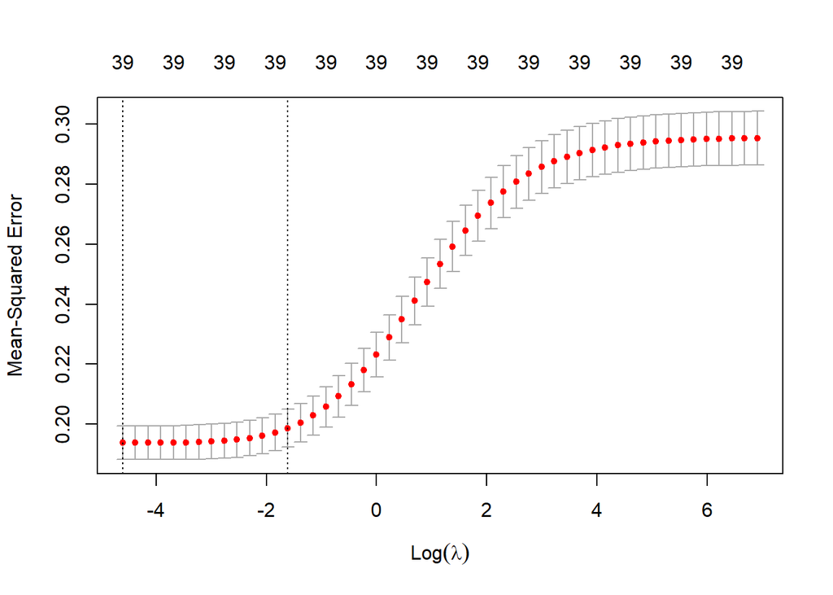

```r
# outcome
y <- listings_reg_nlp$cx_scores

# Predictors as matrix
x <- listings_reg_nlp %>% dplyr::select(-cx_scores) %>% data.matrix()

# Set up the hyperparameter, lambda - this is the strength of the penalty for each residual
lambdas <- 10^seq(3, -2, by = -.1)

# Find optimal lambda using cross-validation - running the model many times for different values of lambda
cv_ridge_model <- cv.glmnet(x, y, alpha = 0, lambda = lambdas)
plot(cv_ridge_model)
```

So we now have the optimal lambda for our value. We can extract this value to work with it:

```r
opt_lambda <- cv_ridge_model$lambda.min
opt_lambda
```

```
## [1] 0.01
```

Now we have our trained models as below:

```r
ridge_model <- cv_ridge_model$glmnet.fit
summary(ridge_model)
```

```
##           Length Class     Mode
## a0          51   -none-    numeric
## beta      1989   dgCMatrix S4
## df          51   -none-    numeric
## dim          2   -none-    numeric
## lambda      51   -none-    numeric
## dev.ratio   51   -none-    numeric
## nulldev      1   -none-    numeric
## npasses      1   -none-    numeric
## jerr         1   -none-    numeric
## offset       1   -none-    logical
## call         5   -none-    call
## nobs         1   -none-    numeric
```

We can also visualize the coefficients as below, where each curve is a variable

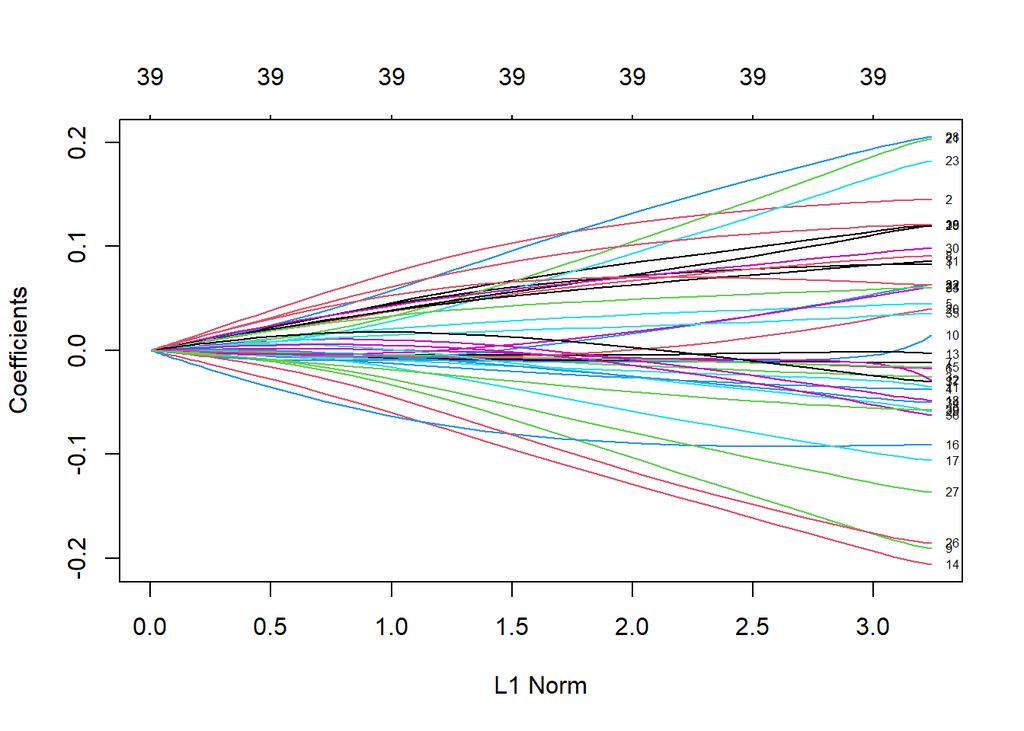

```r
plot(ridge_model, label = TRUE)
```

And we can see how good the training model is:

```r
ridge_y_pred <- predict(ridge_model, s = opt_lambda, newx = x)

# Sum of Squares Total and Error
sst <- sum((y - mean(y))^2)
sse <- sum((ridge_y_pred - y)^2)

# R squared
rsq <- 1 - sse / sst
rsq
```

```
## [1] 0.3531543
```

RMSE

```r
ridge_train <- glmnet(x_train, y_train, alpha=0, lambda = lambdas)
ridge_pred <- predict(ridge_train, s = opt_lambda, newx = x_test)
sqrt(mean((ridge_pred - y_test)^2))
```

```
## [1] 0.4296392
```

#### 5.3. Lasso Regression

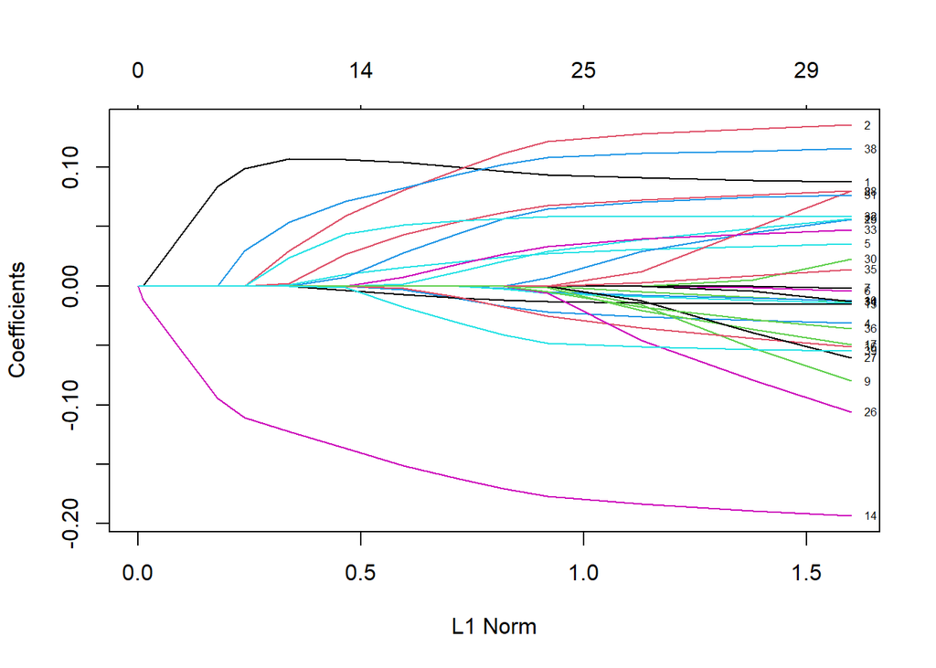

```r
lasso_model <- glmnet(x, y, alpha = 1, lambda = lambdas)
plot(lasso_model, label = TRUE)    # Draw plot of coefficients
```

Notice that in the coefficient plot that depending on the choice of tuning parameter, some of the coefficients are exactly equal to zero. We now perform cross-validation and compute the associated test error:

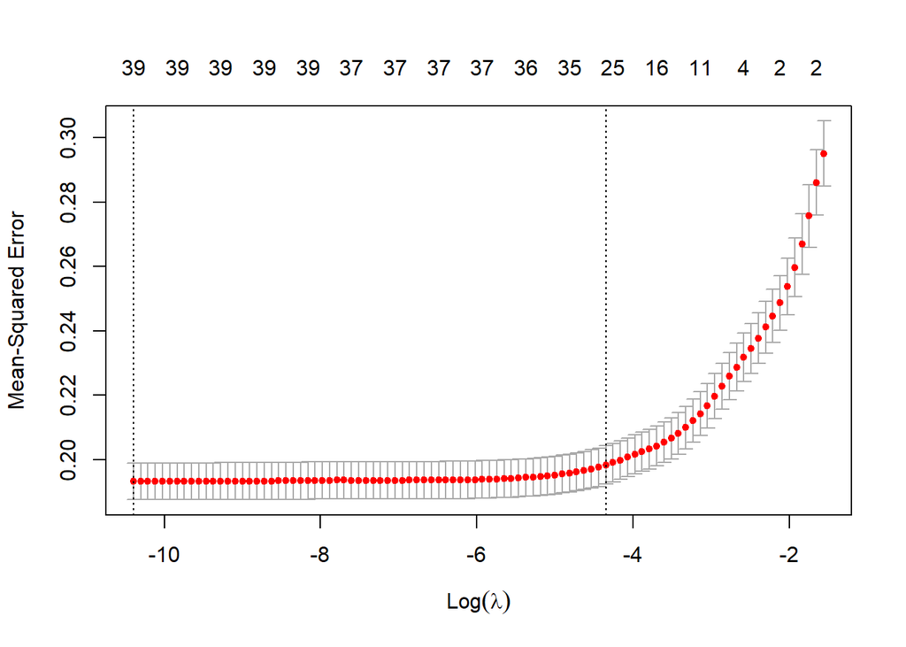

```r
cv_lasso_model <- cv.glmnet(x, y, alpha = 1) # Fit lasso model on training data
plot(cv_lasso_model) # Draw plot of training MSE as a function of lambda
```

The optimal lambda is:

```r
opt_lambda <- cv_lasso_model$lambda.min
lasso_y_pred <- predict(lasso_model, s = opt_lambda, newx = x)
opt_lambda
```

```
## [1] 3.056938e-05
```

And we can see how good the training model is:

```r
# Sum of Squares Total and Error
sst <- sum((y - mean(y))^2)
sse <- sum((lasso_y_pred - y)^2)

# R squared
rsq <- 1 - sse / sst
rsq
```

```
## [1] 0.3405308
```

RMSE

```r
lasso_train <- glmnet(x_train, y_train, alpha=1, lambda = lambdas)
lasso_pred <- predict(lasso_model, s = opt_lambda, newx = x_test) # Use best lambda to predict test data
sqrt(mean((lasso_pred - y_test)^2))
```

```
## [1] 0.4312162
```

#### 5.4. Random Forest

```r
oob.err=double(13)
test.err=double(13)
#mtry is the number of variables randomly chosen at each split
for(mtry in 1:13)
{
  rf=randomForest(cx_scores ~ . , data = train,mtry=mtry,ntree=400)
  oob.err[mtry] = rf$mse[400] #Error of all Trees fitted

  pred<-predict(rf,test) #Predictions on Test Set for each Tree
  test.err[mtry]= with(test, mean((cx_scores - pred)^2)) #Mean Squared Test Error

  cat(mtry," ") #printing the output to the console
}
```

```
## 1  2  3  4  5  6  7  8  9  10  11  12  13
```

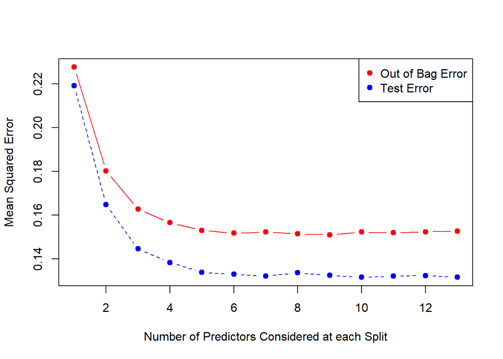

```r
matplot(1:mtry, cbind(oob.err,test.err), pch=19, col=c("red","blue"), type="b", ylab="Mean Squared Error", xlab="Number of Predictors Considered at each Split")
legend("topright", legend=c("Out of Bag Error","Test Error"), pch=19, col=c("red","blue"))
```

```r
rf_model <- randomForest(cx_scores ~ . , data = train, mtry = 7, ntree=300)
rf_model
```

```
##
## Call:
##  randomForest(formula = cx_scores ~ ., data = train, mtry = 7,      ntree = 300)
##                Type of random forest: regression
##                      Number of trees: 300
## No. of variables tried at each split: 7
##
##           Mean of squared residuals: 0.151115
##                     % Var explained: 49.08
```

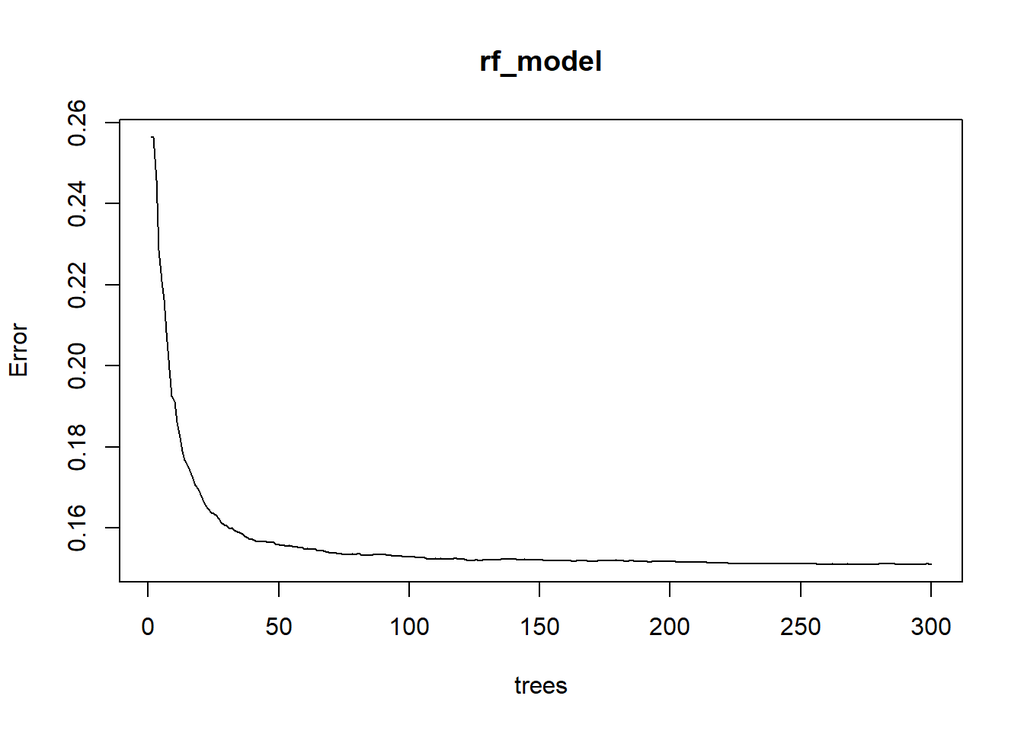

```r
plot(rf_model)
```

RMSE

```r
rf_pred <- predict(rf_model,test)
sqrt(mean((rf_pred - y_test)^2))
```

```
## [1] 0.3633921
```